# Analysis of BSL corpus negations

Bodo Winter

02/06/2020

## Introduction

Analysis of data annotated for negation in the BSL corpus.

Load packages:

```r
library(tidyverse) # for data processing, including ggplot2 graphs
library(gridExtra) # for multi-plotting
library(lsr) # for Cramer's V effect size
library(patchwork) # for multi-plotting for Gab's slides, not used in publication
```

Check R version and package version for reporting:

```r
R.Version()
```

```
## $platform
## [1] "aarch64-apple-darwin20"
##
## $arch
## [1] "aarch64"
##
## $os
## [1] "darwin20"
##
## $system
## [1] "aarch64, darwin20"
##
## $status
## [1] ""
##
## $major
## [1] "4"
##
## $minor
## [1] "4.0"
##
## $year
## [1] "2024"
##
## $month
## [1] "04"
##
## $day
## [1] "24"
##
## $`svn rev`
## [1] "86474"
##
## $language
## [1] "R"
##
## $version.string
## [1] "R version 4.4.0 (2024-04-24)"
##
## $nickname
## [1] "Puppy Cup"
```

```r
packageVersion('tidyverse')
```

```
## [1] '2.0.0'
```

```r
packageVersion('gridExtra')
```

```
## [1] '2.3'
```

```r
packageVersion('lsr')
```

```
## [1] '0.5.2'
```

Load helper functions, which makes “percentage()” and a ggtheme available.

```r
source('negation_helper_functions.R')
```

Load data:

```r
# Original data with Adam's new coding for regular/irregular negation and 4 data points of mouthings re-classified and comments deleted:

neg <- read_csv('../data/BSL_negation_recoded_final_01_12_2022.csv')
```

Show first few rows and all columns:

```r
neg %>% print(n = 2, width = Inf)
```

```
## # A tibble: 504 × 21
##   `ClauseLikeUnit(CLU)-value` regularity Negation       `CLUcomposite-value`
##   <chr>                       <chr>      <chr>          <chr>
## 1 BL03F70WHC_LH_CLU#016       Irregular  Negated clause Single
## 2 BL03F70WHC_LH_CLU#032       ?          Negated clause Single
##   `CLUwithinCLU-value` `CLUcomplex-value` `LitTransl-value`
##   <chr>                <chr>              <chr>
## 1 <NA>                 <NA>               me not understand
## 2 <NA>                 <NA>               me not-understand
##   `FreeTransl-value`
##   <chr>
## 1 There were children signing out there and I couldn't understand any of them.
## 2 As I got indoors, my Mother waved and cried bye bye, but I did not know where…
##   Duration `N-function-value` `N-manual-value` `N-nonmanual-value`
##      <dbl> <chr>              <chr>            <chr>
## 1     1190 Neg/reprise        Multiple         Present
## 2     1140 Neg/declarative    Single           Present
##   `N-position-value` `HeadNegationStudy-value` `CA-value`
##   <chr>              <chr>                     <chr>
## 1 other              HS                        <NA>
## 2 other              HS                        <NA>
##   `MouthGestF-value`        `Mouthing-value` `MouthingNegation-value`
##   <chr>                     <chr>            <chr>
## 1 SYLL:POOH, SYLL:POOH-prog me               Absent
## 2 SYLL:POOH                 bye-prog         Absent
##   `NegSingleClausesMouthing-negator` `RH-IDgloss-value`
##   <chr>                              <chr>
## 1 Absent                             CAN-NOT, NOT-UNDERSTAND
## 2 Absent                             NOT-UNDERSTAND
##   `LH-IDgloss-value`
##   <chr>
## 1 PT:PRO1SG, CAN-NOT, NOT-UNDERSTAND
## 2 PT:PRO1SG, NOT-UNDERSTAND
## # ℹ 502 more rows
```

## Preprocessing and cleaning

Change hyphens in column names to underscores to avoid tidyverse complications:

```r
colnames(neg) <- str_replace_all(colnames(neg), '-', '_')
colnames(neg)[1] <- 'CLU_value'

# Check:

colnames(neg)
```

```
##  [1] "CLU_value"                        "regularity"
##  [3] "Negation"                         "CLUcomposite_value"
##  [5] "CLUwithinCLU_value"               "CLUcomplex_value"
##  [7] "LitTransl_value"                  "FreeTransl_value"
##  [9] "Duration"                         "N_function_value"
## [11] "N_manual_value"                   "N_nonmanual_value"
## [13] "N_position_value"                 "HeadNegationStudy_value"
## [15] "CA_value"                         "MouthGestF_value"
## [17] "Mouthing_value"                   "MouthingNegation_value"
## [19] "NegSingleClausesMouthing_negator" "RH_IDgloss_value"
## [21] "LH_IDgloss_value"
```

Process the string that comes from the filename, which contains information about location, gender, age, ethnicity and handedness.

First, extract location information. The “LocationCode” column will contain the first two letters of the string, which is the two-letter identifier for each city (BM = Birmingham, LN = London, MC = Manchester, BL = Bristol). The “Location” column will contain the full name of the city.

```r
neg <- mutate(neg,
              LocationCode = str_sub(CLU_value, 1, 2),
              Location = ifelse(LocationCode == 'BM', 'Birmingham', LocationCode),
              Location = ifelse(LocationCode == 'LN', 'London', Location),
              Location = ifelse(LocationCode == 'MC', 'Manchester', Location),
              Location = ifelse(LocationCode == 'BL', 'Bristol', Location))
```

Extract the participant identifier. Participants are given a numerical identifier (1 to 35), however, this number is repeated across cities, e.g., we have both “BL07” and “BM07” in this data, which are different individuals. So the city code plus number works as a unique identifier, which is the first four characters of the string.

```r
neg <- mutate(neg,
              Participant = str_sub(CLU_value, 1, 4))
```

Gender information is a single letter (M = male, F = female) that follows the numerical identifier.

```r
neg <- mutate(neg,
              Gender = str_sub(CLU_value, 5, 5))
```

Extract the age information, which follows gender.

```r
neg <- mutate(neg,
              Age = str_sub(CLU_value, 6, 7),
              Age = as.numeric(Age))
```

Extract ethnicity information, which follows age. The codes mean A = Asian, B = Black, W = White. The “EthnicityCode” column will contain the identifier, and the “Ethnicity” column will contain the full label.

```r
neg <- mutate(neg,
              EthnicityCode = str_sub(CLU_value, 8, 8),
              Ethnicity = ifelse(EthnicityCode == 'A', 'Asian', EthnicityCode),
              Ethnicity = ifelse(EthnicityCode == 'B', 'Black', Ethnicity),
              Ethnicity = ifelse(EthnicityCode == 'W', 'White', Ethnicity))
```

Extract information about whether the family is deaf (D) or hearing (H). As before, “FamilyCode” will contain the single-letter character identifier and “Family” the full label.

```r
neg <- mutate(neg,
              FamilyCode = str_sub(CLU_value, 9, 9),
              Family = ifelse(FamilyCode == 'D', 'Deaf', FamilyCode),
              Family = ifelse(FamilyCode == 'H', 'Hearing', Family))
```

Extract information about whether the signer is left- or right-handed. There are no ambidextrous participants in this dataset. All left-hand-dominant signers are marked with “_LH”; the right-handed signers are unmarked.

```r
neg <- mutate(neg,
              HandednessCode = ifelse(str_detect(CLU_value, 'LH'),
                                      'LH', 'RH'),
              Handedness = ifelse(HandednessCode == 'LH',
                                  'left-handed', 'right-handed'))
```

Process the “Negation” column so that “INDEFINITE” is “Indefinite”.

```r
neg <- mutate(neg,
              Negation = ifelse(Negation == 'INDEFINITE',
                                'Indefinite', Negation))
```

The following four items need to be recoded from single to multiple in the `MouthingNegation_value` column:

```r
these_ids <- c('BM13F39WHC_CLU#082', 'LN25M76WHC_CLU#151',
               'MC21F67WHNC_CLU#145', 'MC27F24WDC_CLU#048')

these_rows <- neg$CLU_value %in% these_ids
```

Get those and change the value of the `MouthingNegation_value` column to `Multiple`:

```r
neg[these_rows, ]$MouthingNegation_value <- 'Multiple'
```

## Preprocessing head shakes, mouth gestures, and multi-strategy counts

Create a variable that codes for the presence absence of mouth gestures.

```r
neg <- mutate(neg,
              MouthGesture_YesNo = ifelse(is.na(MouthGestF_value),
                                         'No mouth gesture', 'Mouth gesture'))
```

Rename the head negation column for easier typing and shorter lines:

```r
neg <- rename(neg,
              HS = HeadNegationStudy_value)
```

Check presence of head shaking for negation:

```r
neg %>%
  count(HS, sort = TRUE) %>%
  mutate(Perc = percentage(n)) %>% print(n = Inf)
```

```
## # A tibble: 38 × 3
##    HS                          n Perc
##    <chr>                   <int> <chr>
##  1 HS                        222 44%
##  2 NHS, HS                    79 16%
##  3 NHS                        74 15%
##  4 HS, NHS                    29 6%
##  5 HS1                        16 3%
##  6 NHS, HS, NHS               13 3%
##  7 HS1, NHS                   10 2%
##  8 HS, NHS, HS                 6 1%
##  9 NHS, HS1                    5 1%
## 10 HS , NHS                    4 1%
## 11 HS, Nod                     4 1%
## 12 NHS, HS1, NHS               4 1%
```

[output cut: 26 more lines]

This one is more complex, with 38 unique labels, including many different combinations.

Many of these are due to trailing spaces, e.g., “NHS , HS” is treated as separately from “NHS, HS” because of the extra space. So getting rid of trailing spaces should reduce the number of categories. In other cases, there are missing commas which create artificially separated labels, e.g. ‘HS NHS’ should be the same as ‘HS, NHS’.

```r
neg <- mutate(neg,
              HS = str_replace(HS, ' ,', ''),
              HS = str_replace(HS, 'NHS HS', 'NHS, HS'),
              HS = ifelse(HS == 'NHS, HS? , NHS', 'NHS, HS?, NHS', HS),
              HS = ifelse(HS == 'HS NHS', 'HS, NHS', HS),
              HS = ifelse(HS == 'HS,', 'HS', HS))
```

Check again:

```r
neg %>%
  count(HS, sort = TRUE) %>%
  mutate(Perc = percentage(n)) %>% print(n = Inf)
```

```
## # A tibble: 33 × 3
##    HS                         n Perc
##    <chr>                  <int> <chr>
##  1 HS                       224 44%
##  2 NHS, HS                   82 16%
##  3 NHS                       74 15%
##  4 HS, NHS                   33 7%
##  5 HS1                       16 3%
##  6 NHS, HS, NHS              14 3%
##  7 HS1, NHS                  10 2%
##  8 HS, NHS, HS                6 1%
##  9 NHS, HS1                   5 1%
## 10 HS, Nod                    4 1%
## 11 NHS, HS1, NHS              4 1%
## 12 Nod, HS                    4 1%
```

[output cut: 21 more lines]

Now on to the more substantive (theoretically incisive) re-codings.

So “HS?” is an uncertain case of a headshake, erring on the side of present, whereas “NHS?” is an uncertain case erring on the side of absent. However, there are also combinations of these values with uncertain cases. such as “NHS, HS?”. The question then is whether this should count towards “HS”, since the coding scheme says this “errs on the side of present”. There is only one case of “NHS?”, which means that this is pretty much marginal and can be ignored. This is a questionable case, but it is definitely not a headshake.

I will create a new variable that has the following categories:

- HS only (this will include “HS?” which is very few cases anyway; also multiple HS cases)
- NHS only (no head shake whatsoever; this will also include the single case of “NHS?”)
- NHS > HS (this will include “NHS, HS?”)
- HS > NHS (this will include “HS?, NHS”)
- Other combinations that are more complex than NHS > HS, HS > NHS
- HS combined with nods (this includes cases with NHS)
- Nod only (including “NHS, Nod”)

In this coding scheme, I will treat “HS1” as “HS”, since this would proliferate categories even more. A single head shake is a headshake after all.

```r
combos <- c('NHS, HS, NHS', 'HS, NHS, HS', 'NHS, HS NHS',
            'NHS, HS, HS', # not sure if this should be counted as NHS > HS
            'NHS, HS, NHS, HS', 'NHS, HS, NHS, HS, NHS',
            'NHS, HS, NHS, NHS')
HS_with_nod <- c('HS, Nod', 'Nod, HS', 'NHS, HS, Nod',
                 'NHS, HS, Nod, NHS Nod', 'NHS, HS+Nod', 'Nod, NHS, HS')

neg <- mutate(neg,
              HS_new = str_replace_all(HS, '1', ''),
              HS_new = str_replace_all(HS_new, '\\?', ''),
              HS_new = ifelse(HS_new %in% combos,
                              'Combination with HS', HS_new),
              HS_new = ifelse(HS_new == 'HS, HS',
                              'HS', HS_new),
              HS_new = ifelse(HS_new == 'HS, HS, HS',
                              'HS', HS_new),
              HS_new = ifelse(HS_new %in% HS_with_nod,
                              'HS with nod', HS_new),
              HS_new = ifelse(HS_new == 'NHS, Nod',
                              'Nod', HS_new))
```

Create a variable that codes for whether there is any head shake whatsoever.

```r
no_HS <- c('Nod', 'NHS')
neg <- mutate(neg,
              HS_YesNo = ifelse(!HS_new %in% no_HS, 'Any\nhead shake', 'No\nhead shake'))
```

For this, we will first create a variable which contains information about whether there is ANY manual sign, that is, collapsing the ‘multiple’ and ‘single’ categories:

```r
neg <- mutate(neg,
              Manual_YesNo = ifelse(N_manual_value == 'Absent', 'no manual sign',
                                    'manual sign'),
              Mouthing_YesNo = ifelse(MouthingNegation_value == 'Absent',
                                      'no mouthing', 'mouthing'),
              HS_YesNo = ifelse(HS_YesNo == 'No\nhead shake',
                                'no HS', 'HS'))
```

Create a variable where they are treated numerical, with present = 1 and absent = 0. That way we can add them up. Something that has manual negation and negation in mouthing would then get a “2”, something that additionally has a headshake, will get a “3”, and so on.

```r
neg <- mutate(neg,
              Manual_01 = ifelse(Manual_YesNo == 'no manual sign', 0, 1),
              Mouthing_01 = ifelse(Mouthing_YesNo == 'no mouthing', 0, 1),
              MouthGesture_01 = ifelse(MouthGesture_YesNo == 'No mouth gesture', 0, 1),
              HS_01 = ifelse(HS_YesNo == 'no HS', 0, 1),
              FormSum = Manual_01 + Mouthing_01 + MouthGesture_01 + HS_01)
```

Convert “pre-container, contained” and “pre-container, contained+pre-container” to “Complex”, as well as “contained+contained” to “contained”. Then capitalize the first letter for plotting:

```r
complex <- c('pre-container, contained', 'contained+pre-container',
             'pre-container, contained+pre-container')

neg <- mutate(neg,
              CLUwithin_simple = ifelse(CLUwithinCLU_value %in% complex,
                                        'Combination', CLUwithinCLU_value),
              CLUwithin_simple = ifelse(CLUwithin_simple == 'contained+contained',
                                        'Contained', CLUwithin_simple),
              CLUwithin_simple = str_to_sentence(CLUwithin_simple))
```

## Preprocessing BSL teaching data

In this section, we will incorporate the BSL teaching data.

```r
ppts <- read_csv('../data/ParticipantSpreadsheet11JUN14ANON.csv')
```

Get the relevant column:

```r
ppts <- select(ppts,
               `Overall code`, `Taught BSL`) %>%
  rename(ID = `Overall code`,
         Taught_BSL_YesNo = `Taught BSL`)
```

Extract the ID from the “CLU_value” column:

```r
neg <- mutate(neg,
              ID = str_sub(CLU_value, 1, 9))
```

Merge the “ppts” BSL teaching data into the “neg” data frame:

```r
# Check that they all match:

all(!is.na(match(neg$ID, ppts$ID)))
```

```
## [1] TRUE
```

They do. So let’s merge it in:

```r
neg <- left_join(neg, ppts)
```

Check:

```r
neg$Taught_BSL_YesNo
```

```
##   [1] "N" "N" "N" "N" "N" "N" "N" "N" "N" "N" "N" "N" "N" "N" "N" "N" "N" "N"
##  [19] "N" "N" "N" "N" "N" "N" "N" "N" "N" "N" "N" "N" "N" "N" "N" "N" "N" "N"
##  [37] "N" "N" "N" "N" "N" "N" "N" "N" "N" "N" "N" "N" "N" "N" "N" "N" "N" "N"
##  [55] "N" "N" "Y" "Y" "Y" "Y" "Y" "Y" "Y" "Y" "Y" "Y" "Y" "Y" "Y" "Y" "Y" "Y"
##  [73] "Y" "Y" "Y" "Y" "Y" "Y" "Y" "Y" "Y" "Y" "Y" "Y" "Y" "Y" "Y" "Y" "Y" "Y"
##  [91] "Y" "Y" "Y" "Y" "Y" "N" "N" "N" "N" "N" "N" "N" "N" "N" "N" "N" "N" "N"
## [109] "N" "N" "N" NA  NA  NA  NA  NA  NA  NA  NA  NA  NA  NA  NA  NA  NA  NA
## [127] NA  NA  NA  NA  NA  NA  NA  NA  NA  NA  NA  NA  NA  NA  NA  NA  NA  NA
## [145] NA  NA  NA  NA  NA  NA  NA  NA  NA  NA  NA  NA  NA  NA  NA  NA  NA  NA
## [163] NA  NA  NA  NA  NA  NA  NA  NA  NA  NA  NA  NA  NA  NA  NA  NA  NA  NA
## [181] NA  NA  NA  NA  NA  NA  NA  NA  NA  NA  NA  NA  NA  NA  NA  NA  NA  NA
## [199] NA  NA  NA  NA  NA  NA  NA  NA  NA  NA  NA  NA  NA  NA  NA  NA  NA  NA
## [217] NA  NA  "Y" "Y" "Y" "Y" "Y" "Y" "Y" "Y" "Y" "Y" "Y" "Y" "Y" "Y" NA  NA
## [235] NA  NA  NA  NA  NA  NA  NA  NA  NA  NA  NA  NA  NA  NA  NA  NA  NA  NA
## [253] NA  NA  "Y" "Y" "Y" "Y" "Y" "Y" "Y" "Y" "Y" "Y" "Y" "Y" "Y" "Y" "Y" "Y"
## [271] "Y" "Y" "Y" NA  NA  NA  NA  NA  NA  NA  NA  NA  NA  NA  NA  NA  NA  NA
## [289] NA  NA  NA  NA  NA  NA  NA  NA  NA  NA  NA  NA  NA  NA  NA  NA  NA  NA
## [307] NA  NA  NA  NA  NA  NA  "N" "N" "N" "N" "N" "N" "N" "N" "N" "N" "N" "N"
## [325] "N" "N" "N" "N" "N" "N" "N" "N" "N" "N" "N" "N" "N" "N" "N" "Y" "Y" "Y"
## [343] "Y" "Y" "Y" "Y" "Y" "Y" "Y" "Y" "Y" "Y" "Y" "Y" "Y" "Y" "Y" "Y" "Y" "Y"
## [361] "Y" "Y" "Y" "Y" "Y" "Y" "Y" "Y" NA  NA  NA  NA  NA  NA  NA  NA  NA  NA
## [379] NA  NA  NA  NA  NA  NA  NA  NA  NA  NA  NA  NA  NA  NA  NA  NA  NA  NA
## [397] NA  NA  NA  NA  NA  NA  NA  NA  NA  NA  NA  NA  NA  NA  NA  NA  NA  NA
## [415] NA  NA  NA  NA  NA  NA  NA  NA  NA  NA  "Y" "Y" "Y" "Y" "Y" "N" "N" "N"
## [433] "N" "N" "N" "N" "N" "N" "N" "N" "N" "N" "N" "N" "N" "N" "N" "N" "N" "N"
## [451] "N" "N" "N" "N" "N" "N" "N" "N" "N" "N" "N" "N" "N" "N" "N" "N" "N" "N"
## [469] "N" "N" "N" "N" "N" "N" "N" "N" "N" "N" "N" "N" "N" "N" "N" "N" "N" "N"
## [487] "N" "N" "N" "N" "N" "N" "N" "N" "N" "N" "N" "N" "N" "N" "N" "N" "N" "N"
```

## Overview of sample

This section characterizes the sample and gives an overall overview of the data.

How many data points are there in total?

```r
nrow(neg)
```

```
## [1] 504
```

How many participants are there?

```r
n_distinct(neg$Participant)
```

```
## [1] 40
```

How many men and women?

```r
neg %>%
  count(Gender, Participant) %>%
  select(-(Participant:n)) %>%
  count(Gender)
```

```
## # A tibble: 2 × 2
##   Gender     n
##   <chr>  <int>
## 1 F         20
## 2 M         20
```

How many participants per city?

```r
neg %>%
  count(Location, Participant) %>%
  select(-(Participant:n)) %>%
  count(Location)
```

```
## # A tibble: 4 × 2
##   Location       n
##   <chr>      <int>
## 1 Birmingham    10
## 2 Bristol       10
## 3 London        10
## 4 Manchester    10
```

What is the participant age? (mean, standard deviation, range)

```r
neg %>%
  group_by(Participant) %>%
  summarize(Age = mean(Age)) %>%
  ungroup() %>%
  summarize(AgeMean = mean(Age),
            AgeSD = sd(Age),
            AgeMin = min(Age),
            AgeMax = max(Age))
```

```
## # A tibble: 1 × 4
##   AgeMean AgeSD AgeMin AgeMax
##     <dbl> <dbl>  <dbl>  <dbl>
## 1    47.8  17.8     17     77
```

How many per self-reported ethnicity?

```r
neg %>%
  count(Ethnicity, Participant) %>%
  select(-(Participant:n)) %>%
  count(Ethnicity) %>%
  mutate(Perc = percentage(n))
```

```
## # A tibble: 3 × 3
##   Ethnicity     n Perc
##   <chr>     <int> <chr>
## 1 Asian         1 3%
## 2 Black         3 7%
## 3 White        36 90%
```

How many from deaf or hearing families?

```r
neg %>%
  count(Family, Participant) %>%
  count(Family) %>%
  mutate(Perc = percentage(n))
```

```
## # A tibble: 2 × 3
##   Family      n Perc
##   <chr>   <int> <chr>
## 1 Deaf       16 40%
## 2 Hearing    24 60%
```

How many have taught BSL?

```r
neg %>%
  count(Taught_BSL_YesNo, Participant) %>%
  select(-(Participant:n)) %>%
  count(Taught_BSL_YesNo) %>%
  mutate(Perc = percentage(n))
```

```
## # A tibble: 3 × 3
##   Taught_BSL_YesNo     n Perc
##   <chr>            <int> <chr>
## 1 N                   12 30%
## 2 Y                   10 25%
## 3 <NA>                18 45%
```

How many are left or right-handed?

```r
neg %>%
  count(Handedness, Participant) %>%
  select(-(Participant:n)) %>%
  count(Handedness) %>%
  mutate(Perc = percentage(n))
```

```
## # A tibble: 2 × 3
##   Handedness       n Perc
##   <chr>        <int> <chr>
## 1 left-handed      3 7%
## 2 right-handed    37 92%
```

Look at how many data points there are per participants, as well as the average number and range of data points per participant.

```r
sort(table(neg$Participant))
```

```
##
## BL10 BM05 BL21 MC21 LN12 BL22 BL29 BM08 BL03 BM14 MC28 BM22 MC02 MC23 MC09 BM07
##    2    3    5    5    6    7    7    7    8    8    9   10   10   10   11   12
## BM09 BM13 LN26 MC27 BL07 BM06 LN23 BM21 LN03 LN24 MC10 BL04 BL30 BM10 LN06 LN11
##   12   12   12   12   13   13   13   14   14   14   15   16   16   16   16   17
## LN25 BL09 MC24 BL08 LN05 MC01 LN04 MC22
##   17   18   18   19   19   20   22   26
```

```r
mean(table(neg$Participant))
```

```
## [1] 12.6
```

```r
range(table(neg$Participant))
```

```
## [1]  2 26
```

## Descriptive stats: Negation type

Check negation counts:

```r
neg %>%
  count(Negation, sort = TRUE) %>%
  mutate(Perc = percentage(n))
```

```
## # A tibble: 5 × 3
##   Negation                n Perc
##   <chr>               <int> <chr>
## 1 Negated clause        420 83%
## 2 Non-negated clause     51 10%
## 3 Negated clause?        20 4%
## 4 Indefinite              8 2%
## 5 Non-negated clause?     5 1%
```

Check overall number of question-marked cases versus clear cases:

```r
neg %>%
  mutate(QuestionMark = str_detect(Negation, '\\?')) %>%
  count(QuestionMark) %>%
  mutate(Perc = percentage(n))
```

```
## # A tibble: 2 × 3
##   QuestionMark     n Perc
##   <lgl>        <int> <chr>
## 1 FALSE          479 95%
## 2 TRUE            25 5%
```

Create counts that exclude the ones with question marks:

```r
neg %>%
  mutate(Negation = ifelse(str_detect(Negation, '\\?'),
                           'Uncertain', Negation)) %>%
  count(Negation, sort = TRUE) %>%
  # filter(!str_detect(Negation, '\\?')) %>%
  mutate(Perc = percentage(n))
```

```
## # A tibble: 4 × 3
##   Negation               n Perc
##   <chr>              <int> <chr>
## 1 Negated clause       420 83%
## 2 Non-negated clause    51 10%
## 3 Uncertain             25 5%
## 4 Indefinite             8 2%
```

Make a plot of this:

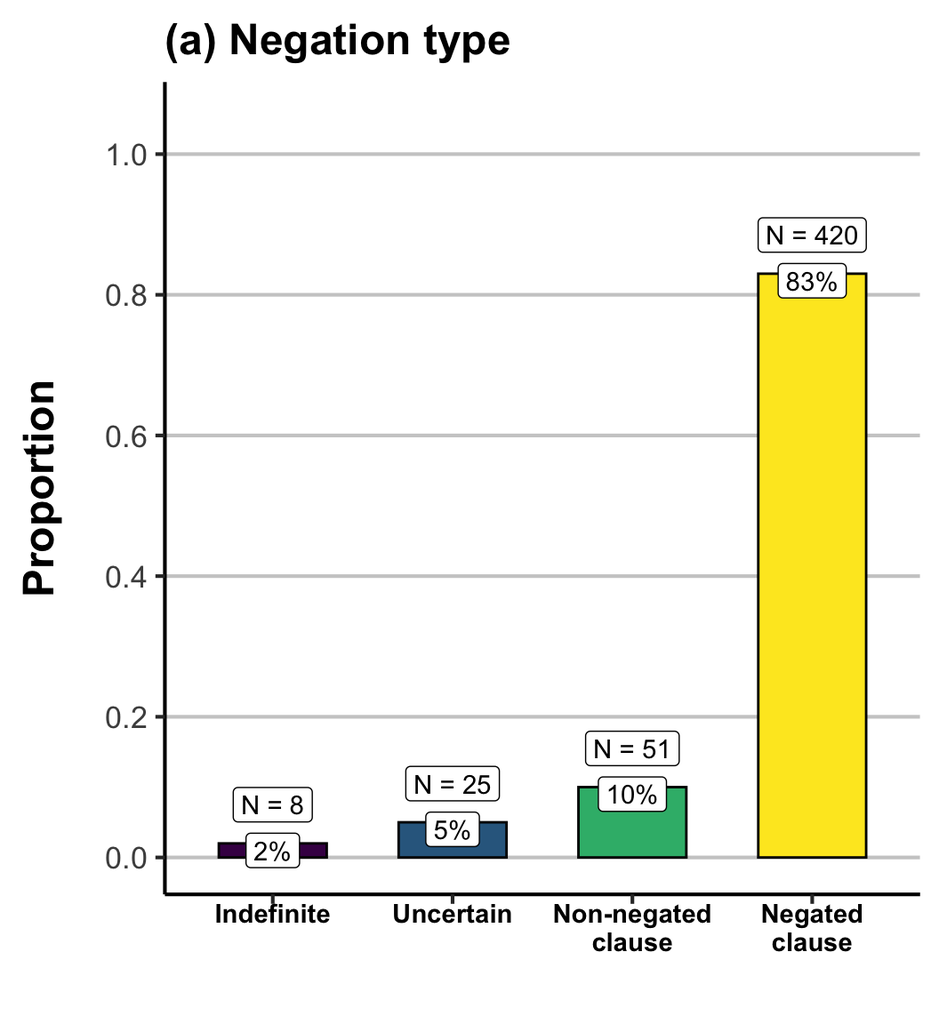

```r
# Data and aesthetics:

neg_p <- neg %>%
  mutate(Negation = ifelse(str_detect(Negation, '\\?'),
                           'Uncertain', Negation)) %>%
  count(Negation, sort = TRUE) %>%
  mutate(Proportion = proportion(n),
         Perc = percentage(n),
         Negation = ifelse(Negation == 'Non-negated clause',
                           'Non-negated\nclause', Negation),
         Negation = ifelse(Negation == 'Negated clause',
                           'Negated\nclause', Negation),
         N = str_c('N = ', n),
         both = str_c(N, '\n', Perc)) %>%
  ggplot(aes(x = reorder(Negation, Proportion),
             y = Proportion, fill = reorder(Negation, Proportion)))

# Add geoms:

neg_p <- neg_p +
  geom_bar(stat = 'identity', col = 'black', width = 0.6) +
  # geom_text(aes(label = N), nudge_y = 0.055) +
  geom_label(aes(label = N), nudge_y = 0.055, fill = 'white') +
  geom_label(aes(label = Perc), nudge_y = -0.01, fill = 'white')
  # geom_label(aes(label = both), nudge_y = 0.01, fill = 'white') # reviewer suggestion

# Add other plot features:

neg_p <- neg_p +
  scale_fill_viridis_d() +
  scale_y_continuous(breaks = seq(0, 1.0, 0.2), limits = c(0, 1.05)) +
  xlab('') +
  ggtitle('(a) Negation type') +
  theme_BSL()

# Plot:

neg_p
```

```r
# Save:

ggsave('../figures/negation_type.pdf', neg_p,
       width = 4.5, height = 5)
ggsave('../figures/negation_type.png', neg_p,
       width = 4.5, height = 5)
```

For the following, we will only consider the negated clauses (N = 420).

```r
neg <- filter(neg,
              Negation == 'Negated clause')
```

## Descriptive stats: Clause type

Check CLU (Clause Like Unit) type counts:

```r
neg %>%
  count(CLUcomposite_value, sort = TRUE) %>%
  mutate(Perc = percentage(n)) %>%
  filter(str_detect(CLUcomposite_value, '\\?')) %>%
  summarize(n = sum(n))
```

```
## # A tibble: 1 × 1
##       n
##   <int>
## 1    23
```

Check overall number of question-marked cases versus clear cases:

```r
neg %>%
  mutate(CLUcomposite_value = str_detect(CLUcomposite_value, '\\?')) %>%
  count(CLUcomposite_value) %>%
  mutate(Perc = percentage(n))
```

```
## # A tibble: 2 × 3
##   CLUcomposite_value     n Perc
##   <lgl>              <int> <chr>
## 1 FALSE                397 95%
## 2 TRUE                  23 5%
```

Create counts that combine the ones with question marks:

```r
neg %>%
  mutate(CLUcomposite_value = ifelse(str_detect(CLUcomposite_value, '\\?'),
                           'Uncertain', CLUcomposite_value)) %>%
  count(CLUcomposite_value, sort = TRUE) %>%
  # filter(!str_detect(CLUcomposite_value, '\\?')) %>%
  mutate(Perc = percentage(n))
```

```
## # A tibble: 9 × 3
##   CLUcomposite_value     n Perc
##   <chr>              <int> <chr>
## 1 Single               322 77%
## 2 Depend                30 7%
## 3 Uncertain             23 5%
## 4 Embed                 22 5%
## 5 SharedCecho           11 3%
## 6 EmbedDepend            7 2%
## 7 EmbedEmbed             3 1%
## 8 DependEmbed            1 0%
## 9 Fragment               1 0%
```

Create a new column out of the old one “CLU_simplified” which merges all the combinations (EmbedEmbed, DependDepend, DependEmbed, and EmbedDepend).

```r
# Combine combinations:

combinations <- c('EmbedDepend', 'DependEmbed', 'EmbedEmbed', 'DependDepend')
neg <- mutate(neg,
              CLU_simplified = ifelse(CLUcomposite_value %in% combinations,
                                      'Combination', CLUcomposite_value))
```

Convert questionable cases to a new label ‘Uncertain’ for this new simplified variable only. This will simplify plotting.

```r
neg <- mutate(neg,
              CLU_simplified = ifelse(str_detect(CLU_simplified, '\\?'),
                                      'Uncertain', CLU_simplified))
```

Create counts for this new variable:

```r
neg %>%
  count(CLU_simplified, sort = TRUE) %>%
  filter(!CLU_simplified %in% c('Questionable','Fragment')) %>%
  mutate(Perc = percentage(n))
```

```
## # A tibble: 6 × 3
##   CLU_simplified     n Perc
##   <chr>          <int> <chr>
## 1 Single           322 77%
## 2 Depend            30 7%
## 3 Uncertain         23 5%
## 4 Embed             22 5%
## 5 Combination       11 3%
## 6 SharedCecho       11 3%
```

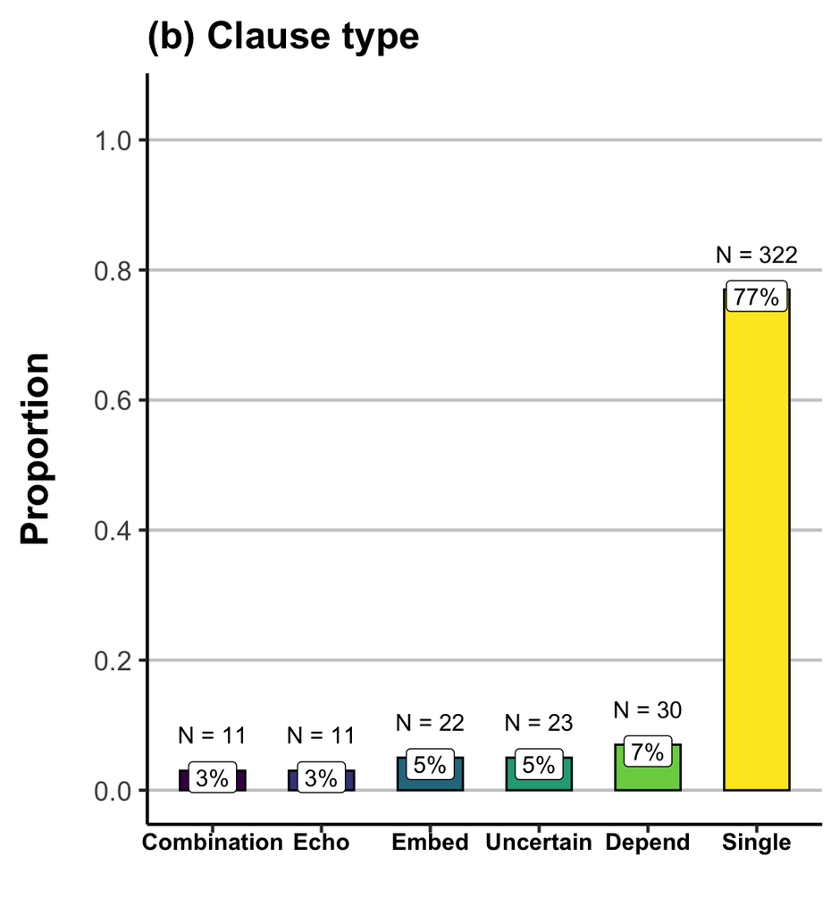

```r
# Data and aesthetics:

CLU_p <- neg %>%
  filter(!CLU_simplified %in% c('Fragment')) %>%
  count(CLU_simplified, sort = TRUE) %>%
  mutate(CLU_simplified = ifelse(CLU_simplified == 'SharedCecho',
                                 'Echo', CLU_simplified),
         Proportion = proportion(n),
         Perc = percentage(n),
         N = str_c('N = ', n)) %>%
  ggplot(aes(x = reorder(CLU_simplified, Proportion),
             y = Proportion, fill = reorder(CLU_simplified, Proportion)))

# Add geoms:

CLU_p <- CLU_p +
  geom_bar(stat = 'identity', col = 'black', width = 0.6) +
  geom_text(aes(label = N), nudge_y = 0.055) +
  geom_label(aes(label = Perc), nudge_y = -0.01, fill = 'white')

# Add other plot features:

CLU_p <- CLU_p +
  scale_fill_viridis_d() +
  scale_y_continuous(breaks = seq(0, 1.0, 0.2), limits = c(0, 1.05)) +
  xlab('') +
  ggtitle('(b) Clause type') +
  theme_BSL()

# Plot:

CLU_p
```

```r
# Save:

ggsave('../figures/CLU_type.pdf', CLU_p,
       width = 6.5, height = 5)
ggsave('../figures/CLU_type.png', CLU_p,
       width = 6.5, height = 5)
```

## Double plot: Clause type & negation type

Make a matrix out of this:

```r
fig1_matrix <- matrix(c(1, 1, 1, 1, 1, 2, 2, 2, 2, 2, 2),
                      nrow = 1)
```

Put both of these into a joint plot with gridExtra:

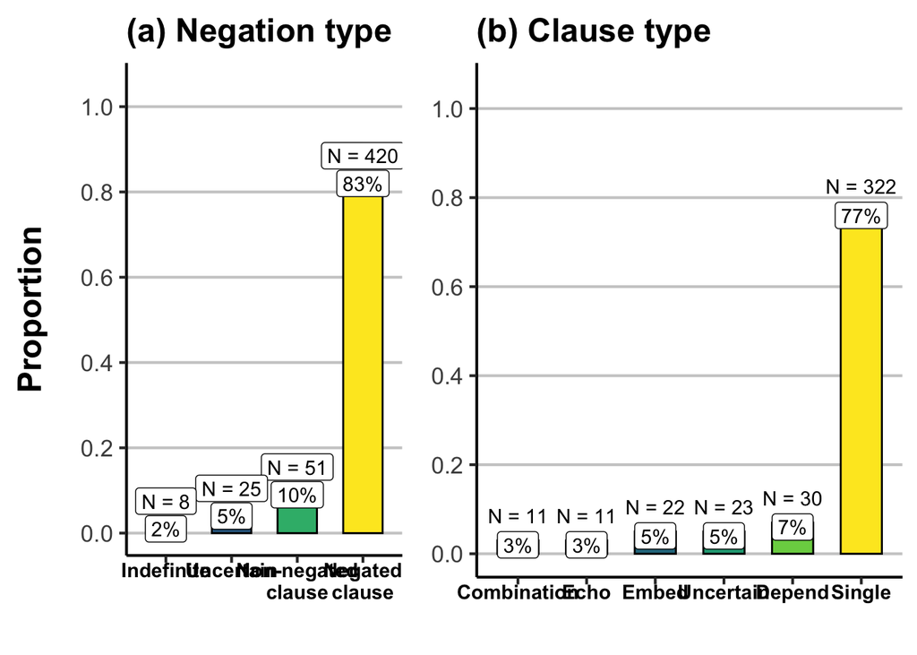

```r
# When included in double plot, we don't need y-axis label for the (b) plot again:

CLU_p <- CLU_p +
  ylab(NULL)

fig1 <- grid.arrange(neg_p, CLU_p,
                     layout_matrix = fig1_matrix)
```

```r
# Save:

ggsave('../figures/negation_clause_type_both.pdf', fig1,
       width = 12, height = 5)
ggsave('../figures/negation_clause_type_both.png', fig1,
       width = 12, height = 5)
```

## Split dataset based on single versus complex clauses

Take a backup:

```r
# Make a backup just in case:
neg_full <- neg
```

Work only with single clause negations from now on, but we also want the same for complex:

```r
compl <- filter(neg,
                CLU_simplified != 'Single') %>%
  filter(CLU_simplified != 'Fragment')

neg <- filter(neg,
              CLU_simplified == 'Single')
```

## Descriptive stats: Function of negation

Check counts:

```r
neg %>%
  count(N_function_value, sort = TRUE) %>%
  filter(!is.na(N_function_value)) %>%
  mutate(Perc = percentage(n))
```

```
## # A tibble: 6 × 3
##   N_function_value      n Perc
##   <chr>             <int> <chr>
## 1 Neg/declarative     170 53%
## 2 Neg/response        115 36%
## 3 Neg/interrogative    15 5%
## 4 Neg/reprise          12 4%
## 5 Neg/imperative        7 2%
## 6 Neg/alternative       3 1%
```

Make a plot of the single ones:

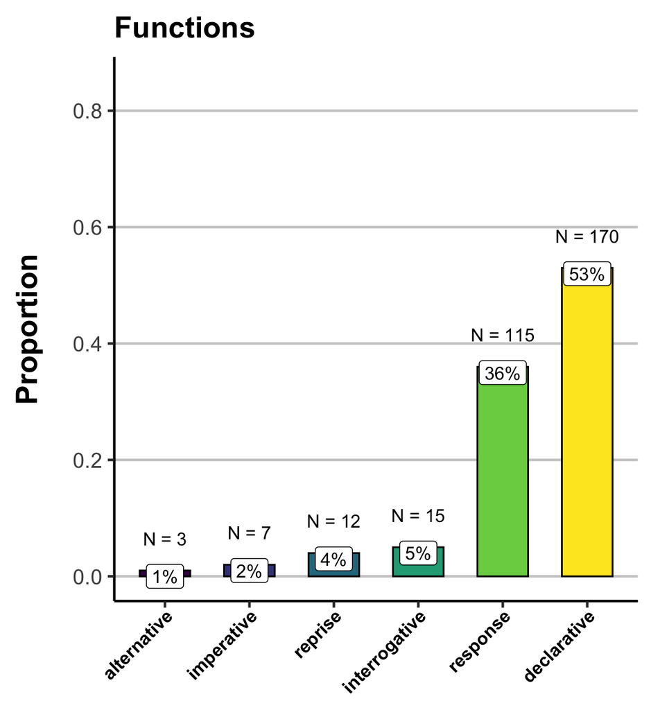

```r
# Data and aesthetics:

function_p <- neg %>%
  count(N_function_value, sort = TRUE) %>%
  filter(!is.na(N_function_value)) %>%
  mutate(N_function_value = str_replace(N_function_value, 'Neg/', ''),
         Proportion = proportion(n),
         Perc = percentage(n),
         N = str_c('N = ', n)) %>%
  ggplot(aes(x = reorder(N_function_value, Proportion),
             y = Proportion, fill = reorder(N_function_value, Proportion)))

# Add geoms:

function_p <- function_p +
  geom_bar(stat = 'identity', col = 'black', width = 0.6) +
  geom_text(aes(label = N), nudge_y = 0.055) +
  geom_label(aes(label = Perc), nudge_y = -0.01, fill = 'white')

# Add other plot features:

function_p <- function_p +
  scale_fill_viridis_d() +
  scale_y_continuous(breaks = seq(0, 1.0, 0.2), limits = c(0, 0.85)) +
  xlab(NULL) +
  ggtitle('Functions') +
  theme_BSL_45()

# Plot:

function_p
```

```r
# Save:

ggsave('../figures/function.pdf', function_p,
       width = 6.5, height = 5)
ggsave('../figures/function.png', function_p,
       width = 6.5, height = 5)
```

Make a horizontal graph (June 28, 2021; new instructions by Gab):

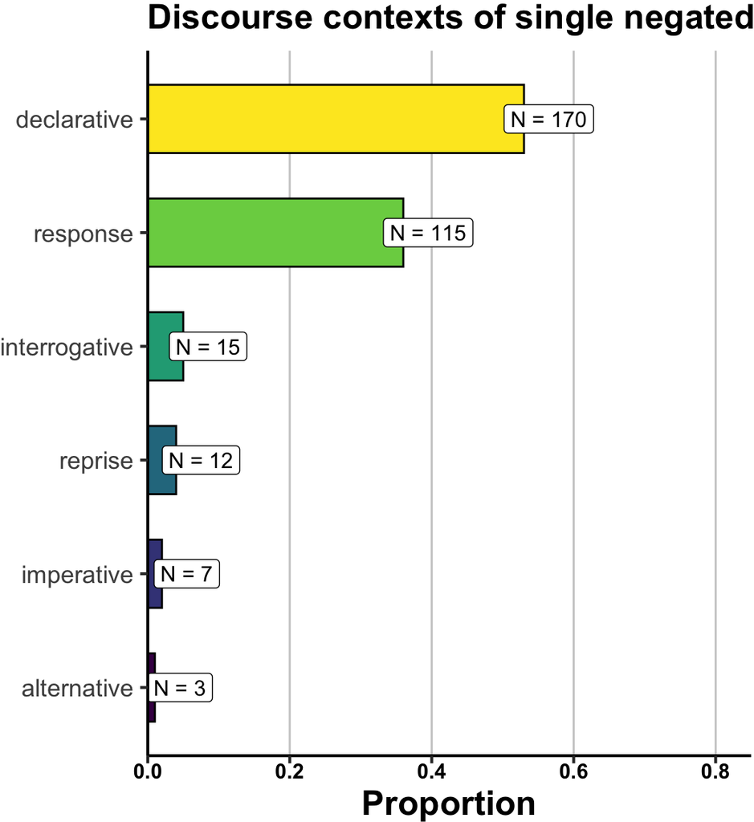

```r
# Data and aesthetics:

function_p <- neg %>%
  count(N_function_value, sort = TRUE) %>%
  filter(!is.na(N_function_value)) %>%
  mutate(N_function_value = str_replace(N_function_value, 'Neg/', ''),
         Proportion = proportion(n),
         Perc = percentage(n),
         N = str_c('N = ', n)) %>%
  ggplot(aes(x = reorder(N_function_value, Proportion),
             y = Proportion, fill = reorder(N_function_value, Proportion)))

# Add geoms:

function_p <- function_p +
  geom_hline(yintercept = seq(0.2, 0.8, 0.2), color = 'grey80') +
  geom_bar(stat = 'identity', col = 'black', width = 0.6) +
  geom_label(aes(label = N), nudge_y = 0.035,
             fill = 'white', size = 4, hjust = 0.5)

# Add other plot features:

function_p <- function_p +
  scale_fill_viridis_d() +
  scale_y_continuous(breaks = seq(0, 1.0, 0.2), limits = c(0, 0.85),
                     expand = c(0, 0)) +
  xlab(NULL) +
  ggtitle('Discourse contexts of single negated clauses') +
  theme_BSL_horizontal() +
  theme(plot.margin = margin(r = 1.5))

# Plot:

function_p <- function_p + coord_flip()

# Save:

function_p
```

```r
ggsave('../figures/function_horizontal.pdf',
       function_p, width = 6.5, height = 4)
ggsave('../figures/function_horizontal.png',
       function_p, width = 6.5, height = 4)
```

## Descriptive stats: Manual negation

How many of negations are signalled via manual signs?

```r
neg %>%
  count(N_manual_value, sort = TRUE) %>%
  mutate(Perc = percentage(n))
```

```
## # A tibble: 3 × 3
##   N_manual_value     n Perc
##   <chr>          <int> <chr>
## 1 Single           196 61%
## 2 Absent            89 28%
## 3 Multiple          37 11%
```

For reporting, get the counts of those cases with any manual sign (single + multiple):

```r
neg %>%
  mutate(N_manual_value = ifelse(N_manual_value == 'Absent',
                                 'no manual', 'manual')) %>%
  count(N_manual_value, sort = TRUE) %>%
  mutate(Perc = percentage(n))
```

```
## # A tibble: 2 × 3
##   N_manual_value     n Perc
##   <chr>          <int> <chr>
## 1 manual           233 72%
## 2 no manual         89 28%
```

Make a plot of this.

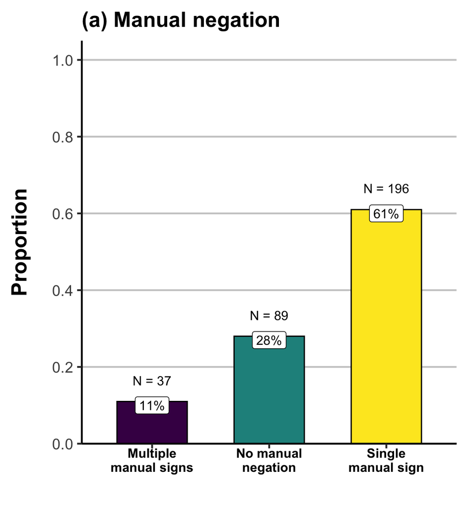

```r
# Data and aesthetics:

manual_p <- neg %>%
  count(N_manual_value, sort = TRUE) %>%
  mutate(N_manual_value = ifelse(N_manual_value == 'Single',
                                 'Single\nmanual sign', N_manual_value),
         N_manual_value = ifelse(N_manual_value == 'Multiple',
                                 'Multiple\nmanual signs', N_manual_value),
         N_manual_value = ifelse(N_manual_value == 'Absent',
                                 'No manual\nnegation', N_manual_value),
         Proportion = proportion(n),
         Perc = percentage(n),
         N = str_c('N = ', n)) %>%
  ggplot(aes(x = reorder(N_manual_value, Proportion),
             y = Proportion, fill = reorder(N_manual_value, Proportion)))

# Add geoms:

manual_p <- manual_p +
  geom_bar(stat = 'identity', col = 'black', width = 0.6) +
  geom_text(aes(label = N), nudge_y = 0.055) +
  geom_label(aes(label = Perc), nudge_y = -0.01, fill = 'white')

# Add other plot features:

manual_p <- manual_p +
  scale_fill_viridis_d() +
  scale_y_continuous(breaks = seq(0, 1.0, 0.2), limits = c(0, 1.05),
                     expand = c(0, 0)) +
  xlab('') +
  ggtitle('(a) Manual negation') +
  theme_BSL()

# Plot:

manual_p
```

```r
# Save:

ggsave('../figures/manual_type.pdf', manual_p,
       width = 6.5, height = 5)
ggsave('../figures/manual_type.png', manual_p,
       width = 6.5, height = 5)
```

Create table of the exact counts, using only the signer’s dominant hand. First, extract the manuals into a separated dataset:

```r
manuals <- filter(neg, N_manual_value != 'Absent')
```

Then the rightie and the leftie dataset:

```r
# Extract subsets:

righties <- filter(manuals, Handedness == 'right-handed')
lefties <- filter(manuals, Handedness == 'left-handed')

# Count:

right_counts <- righties %>%
  count(N_manual_value, RH_IDgloss_value, sort = TRUE) %>%
  rename(DominantGloss = RH_IDgloss_value)
left_counts <- lefties %>%
  count(N_manual_value, LH_IDgloss_value, sort = TRUE) %>%
  rename(DominantGloss = LH_IDgloss_value)

# Add rightie/leftie info:

right_counts$Handedness <- 'right-handed'
left_counts$Handedness <- 'left-handed'

# Put them together again:

manual_glosses <- bind_rows(right_counts, left_counts) %>%
  arrange(desc(n))

# Show:

manual_glosses
```

```
## # A tibble: 208 × 4
##    N_manual_value DominantGloss                   n Handedness
##    <chr>          <chr>                       <int> <chr>
##  1 Single         KNOW-NOT, PT:PRO1SG             7 right-handed
##  2 Single         <NA>                            5 right-handed
##  3 Single         KNOW-NOT                        3 right-handed
##  4 Single         NOT-YET                         3 right-handed
##  5 Single         PT:PRO1SG, NOTHING              3 right-handed
##  6 Multiple       NO, DEAF, NO                    2 right-handed
##  7 Single         CAN-NOT                         2 right-handed
##  8 Single         KNOW-NOT, PT:PRO1SG, G:WELL     2 right-handed
##  9 Single         NOT                             2 right-handed
## 10 Single         NOTHING                         2 right-handed
## # ℹ 198 more rows
```

```r
# Save:

write_csv(manual_glosses, '../manual_glosses_dominant_hand_only.csv')
```

Just in case, also give Gab the full glosses for each hand:

```r
manuals %>% count(N_manual_value, RH_IDgloss_value, sort = TRUE) %>%
  write_csv('../right_gloss_counts_all.csv')

manuals %>% count(N_manual_value, LH_IDgloss_value, sort = TRUE) %>%
  write_csv('../left_gloss_counts_all.csv')
```

Are there any manuals that have no glosses for either?

```r
filter(manuals, is.na(LH_IDgloss_value), is.na(RH_IDgloss_value))
```

```
## # A tibble: 0 × 46
## # ℹ 46 variables: CLU_value <chr>, regularity <chr>, Negation <chr>,
## #   CLUcomposite_value <chr>, CLUwithinCLU_value <chr>, CLUcomplex_value <chr>,
## #   LitTransl_value <chr>, FreeTransl_value <chr>, Duration <dbl>,
## #   N_function_value <chr>, N_manual_value <chr>, N_nonmanual_value <chr>,
## #   N_position_value <chr>, HS <chr>, CA_value <chr>, MouthGestF_value <chr>,
## #   Mouthing_value <chr>, MouthingNegation_value <chr>,
## #   NegSingleClausesMouthing_negator <chr>, RH_IDgloss_value <chr>, …
```

No, so that’s good!

Check position of manual negators:

```r
manuals %>% count(N_position_value, sort = TRUE) %>%
  mutate(prop = n / sum(n),
         `%` = str_c(round(prop, 2) * 100, '%')) %>%
  select(-prop) %>%
  write_csv('../positions.csv') %>%
  print(n = Inf)
```

```
## # A tibble: 7 × 3
##   N_position_value                                n `%`
##   <chr>                                       <int> <chr>
## 1 other                                         124 53%
## 2 pre-predicate                                  43 18%
## 3 post-predicate (non-reprise & clause-final)    33 14%
## 4 reprise (clause-final)                         21 9%
## 5 reprise (non-clause-final)                      6 3%
## 6 post-predicate (non-reprise)                    4 2%
## 7 <NA>                                            2 1%
```

## Descriptive stats: Non-manual negation

See whether there is or isn’t non-manual negation.

```r
neg %>%
  count(N_nonmanual_value , sort = TRUE) %>%
  mutate(Perc = percentage(n))
```

```
## # A tibble: 2 × 3
##   N_nonmanual_value     n Perc
##   <chr>             <int> <chr>
## 1 Present             314 98%
## 2 Absent                8 2%
```

Make a plot of this.

** Bodo Winter July 10, 2025 **: Reviewer remarked on label clipping for the lower category (no non-manual negation) as it gets too close to the bottom y-axis. Fixing this requires setting different nudges for the two categories, which I’ll do by setting a separate nudge variable.

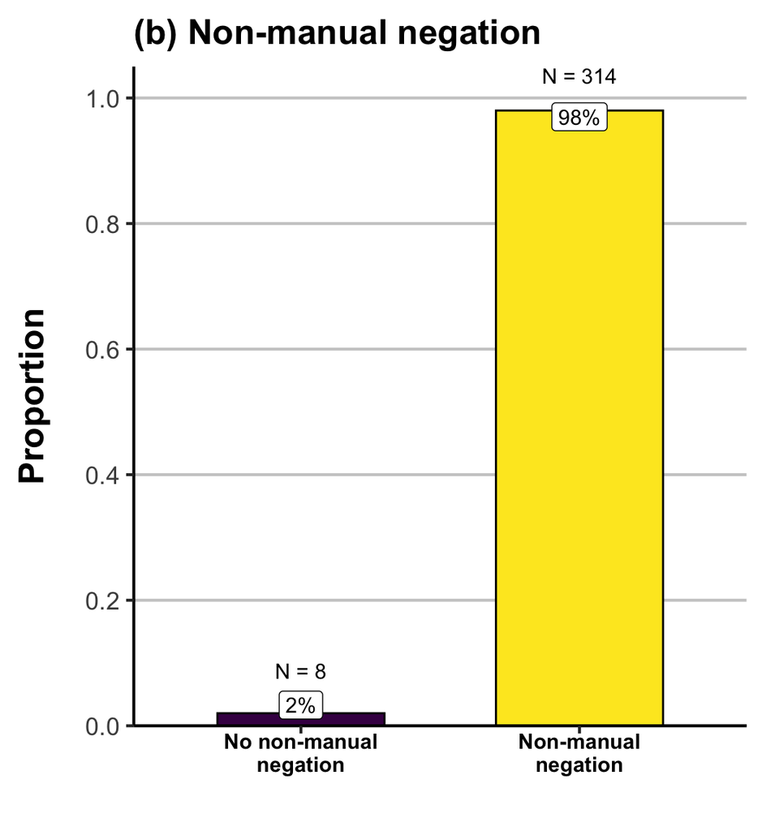

```r
# Data and aesthetics:

nonmanual_p <- neg %>%
  count(N_nonmanual_value , sort = TRUE) %>%
  mutate(N_nonmanual_value = ifelse(N_nonmanual_value == 'Present',
                                    'Non-manual\nnegation',
                                    'No non-manual\nnegation'),
         Proportion = proportion(n),
         Perc = percentage(n),
         N = str_c('N = ', n),
         label_nudges = c(-0.01, 0.013),
         text_nudges = c(0.055, 0.055 + 0.013)) %>%
  ggplot(aes(x = reorder(N_nonmanual_value, Proportion),
             y = Proportion, fill = reorder(N_nonmanual_value, Proportion)))

# Add geoms:

nonmanual_p <- nonmanual_p +
  geom_bar(stat = 'identity', col = 'black', width = 0.6) +
  geom_text(aes(label = N, y = Proportion + text_nudges)) +
  geom_label(aes(y = Proportion + label_nudges, label = Perc), fill = 'white')

# Add other plot features:

nonmanual_p <- nonmanual_p +
  scale_fill_viridis_d() +
  scale_y_continuous(breaks = seq(0, 1.0, 0.2), limits = c(0, 1.05),
                     expand = c(0, 0)) +
  xlab('') +
  ggtitle('(b) Non-manual negation') +
  theme_BSL()

# Plot:

nonmanual_p
```

```r
# Save:

ggsave('../figures/nonmanual_type.pdf', nonmanual_p,
       width = 6.5, height = 5)
ggsave('../figures/nonmanual_type.png', nonmanual_p,
       width = 6.5, height = 5)
```

## Double plot: Manual and non-manual

```r
CLU_matrix <- matrix(c(1, 1, 1, 1, 1, 1, 2, 2, 2, 2),
                      nrow = 1)
```

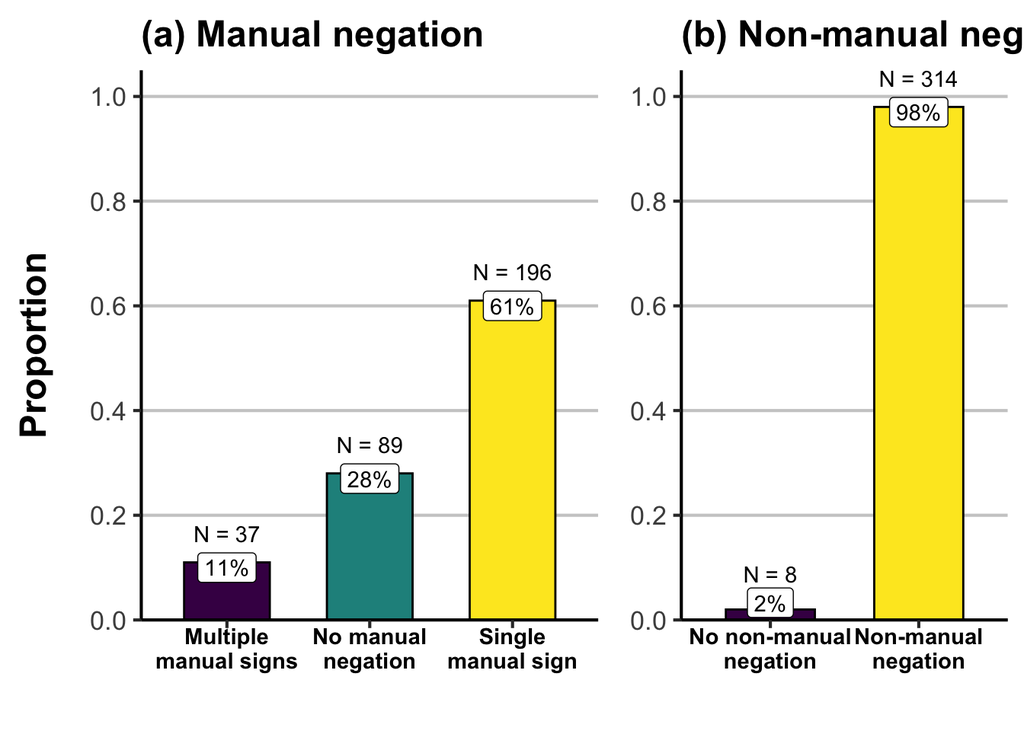

```r
# When included in double plot, we don't need y-axis label for the (b) plot again:

nonmanual_p <- nonmanual_p +
  ylab(NULL)

manual_both_p <- grid.arrange(manual_p, nonmanual_p,
                              layout_matrix = CLU_matrix)
```

```r
# Save:

ggsave('../figures/manual_vs_nonmanual.pdf', manual_both_p,
       width = 10.5, height = 5)
ggsave('../figures/manual_vs_nonmanual.png', manual_both_p,
       width = 10.5, height = 5)
```

## Descriptive stats: Negation in mouthing

Check the presence absence of negation in mouthing or not.

```r
neg %>%
  count(MouthingNegation_value, sort = TRUE) %>%
  mutate(Perc = percentage(n))
```

```
## # A tibble: 3 × 3
##   MouthingNegation_value     n Perc
##   <chr>                  <int> <chr>
## 1 Single                   167 52%
## 2 Absent                   127 39%
## 3 Multiple                  28 9%
```

For reporting, it’ll also be good to just mention the number of mouthing-negations (single + multiple) versus those without (absent):

```r
neg %>%
  mutate(MouthingNegation_value = ifelse(MouthingNegation_value == 'Absent',
                                         'no mouthing', 'mouthing')) %>%
  count(MouthingNegation_value, sort = TRUE) %>%
  mutate(Perc = percentage(n))
```

```
## # A tibble: 2 × 3
##   MouthingNegation_value     n Perc
##   <chr>                  <int> <chr>
## 1 mouthing                 195 61%
## 2 no mouthing              127 39%
```

Make a plot of this.

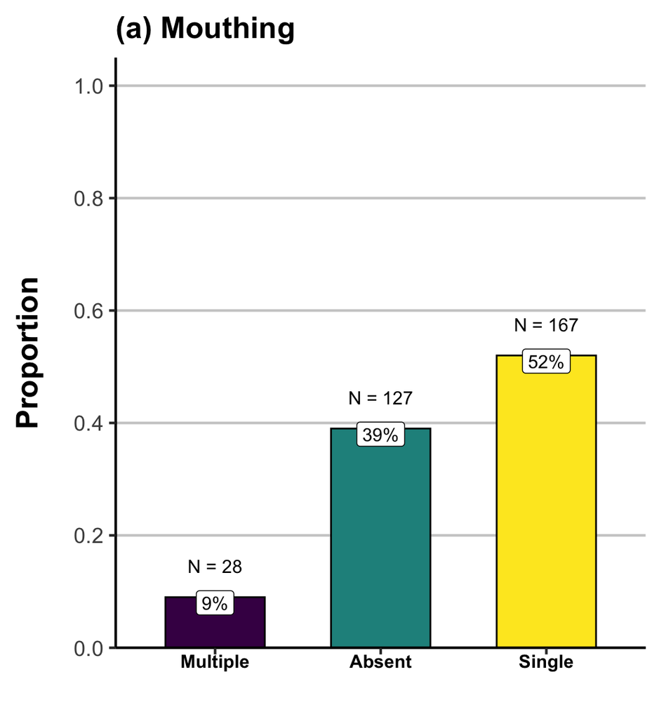

```r
# Data and aesthetics:

mouthing_p <- neg %>%
  count(MouthingNegation_value, sort = TRUE) %>%
  mutate(Proportion = proportion(n),
         Perc = percentage(n),
         N = str_c('N = ', n)) %>%
  ggplot(aes(x = reorder(MouthingNegation_value, Proportion),
             y = Proportion, fill = reorder(MouthingNegation_value, Proportion)))

# Add geoms:

mouthing_p <- mouthing_p +
  geom_bar(stat = 'identity', col = 'black', width = 0.6) +
  geom_text(aes(label = N), nudge_y = 0.055) +
  geom_label(aes(label = Perc), nudge_y = -0.01, fill = 'white')

# Add other plot features:

mouthing_p <- mouthing_p +
  scale_fill_viridis_d() +
  scale_y_continuous(breaks = seq(0, 1.0, 0.2), limits = c(0, 1.05),
                     expand = c(0, 0)) +
  xlab('') +
  ggtitle('(a) Mouthing') +
  theme_BSL()

# Plot:

mouthing_p
```

```r
# Save:

ggsave('../figures/mouthing_negation.pdf', mouthing_p,
       width = 6.5, height = 5)
ggsave('../figures/mouthing_negation.png', mouthing_p,
       width = 6.5, height = 5)
```

What types of mouthings are they? (check glosses)

```r
neg %>%
  filter(!is.na(Mouthing_value)) %>%
  count(Mouthing_value, sort = TRUE) %>%
  mutate(Perc = percentage(n)) %>%
  print(n = 20)
```

```
## # A tibble: 249 × 3
##    Mouthing_value                n Perc
##    <chr>                     <int> <chr>
##  1 don't know                    8 3%
##  2 can't                         5 2%
##  3 nothing                       5 2%
##  4 no                            4 1%
##  5 me                            3 1%
##  6 never, heard                  3 1%
##  7 but                           2 1%
##  8 can't afford                  2 1%
##  9 don't                         2 1%
## 10 i don't know                  2 1%
## 11 money                         2 1%
## 12 no money                      2 1%
## 13 not yet                       2 1%
## 14 not, no                       2 1%
## 15 pub                           2 1%
## 16 (be)fore, olympics            1 0%
## 17 (diffi)cult, age, or          1 0%
## 18 (y)ou, going, out tonight     1 0%
## 19 Annette, not allowed          1 0%
## 20 England, first, half          1 0%
## # ℹ 229 more rows
```

**Update Dec 1/2022**: New data from Adam and Kearsy about mouthings being recoded:

```r
neg %>%
  filter(NegSingleClausesMouthing_negator != 'Absent') %>%
  filter(NegSingleClausesMouthing_negator != 'Multiple') %>%
  filter(NegSingleClausesMouthing_negator != 'Multiple?') %>%
  count(NegSingleClausesMouthing_negator, sort = TRUE) %>%
  mutate(Perc = percentage(n)) %>%
  print(n = 20)
```

```
## # A tibble: 13 × 3
##    NegSingleClausesMouthing_negator     n Perc
##    <chr>                            <int> <chr>
##  1 not                                 48 29%
##  2 don't                               35 21%
##  3 can't                               21 13%
##  4 no                                  19 11%
##  5 nothing                             18 11%
##  6 never                                9 5%
##  7 won't                                7 4%
##  8 didn't                               4 2%
##  9 doesn't                              2 1%
## 10 couldn't                             1 1%
## 11 haven't                              1 1%
## 12 no one                               1 1%
## 13 shouldn't                            1 1%
```

## Descriptive stats: Mouth gestures

Count the presence/absence of mouth gesture variable:

```r
neg %>%
  count(MouthGesture_YesNo, sort = TRUE) %>%
  mutate(Perc = percentage(n))
```

```
## # A tibble: 2 × 3
##   MouthGesture_YesNo     n Perc
##   <chr>              <int> <chr>
## 1 No mouth gesture     239 74%
## 2 Mouth gesture         83 26%
```

What mouth gestures are there? (check glosses)

```r
neg %>%
  filter(!is.na(MouthGestF_value)) %>%
  count(MouthGestF_value, sort = TRUE) %>%
  mutate(Perc = percentage(n))
```

```
## # A tibble: 17 × 3
##    MouthGestF_value                 n Perc
##    <chr>                        <int> <chr>
##  1 PRESSED-LIPS                    53 64%
##  2 SYLL:POOH                        9 11%
##  3 SYLL:SHH                         4 5%
##  4 CA:PRESSED-LIPS                  2 2%
##  5 SYLL:ATH                         2 2%
##  6 SYLL:THH                         2 2%
##  7 ACTION:SMILING                   1 1%
##  8 CA:EXPRESSION, CA:EXPRESSION     1 1%
##  9 CA:TH                            1 1%
## 10 CWF                              1 1%
## 11 EXPRESSION                       1 1%
## 12 PRESSED-LIPS, PRESSED-LIPS       1 1%
## 13 SYLL:ATH, PRESSED-LIPS           1 1%
## 14 SYLL:FOO                         1 1%
## 15 SYLL:HALP, PRESSED-LIPS          1 1%
## 16 SYLL:POOH, SYLL:POOH-prog        1 1%
## 17 SYLL:SHH, SYLL:SHH               1 1%
```

Make a plot of this.

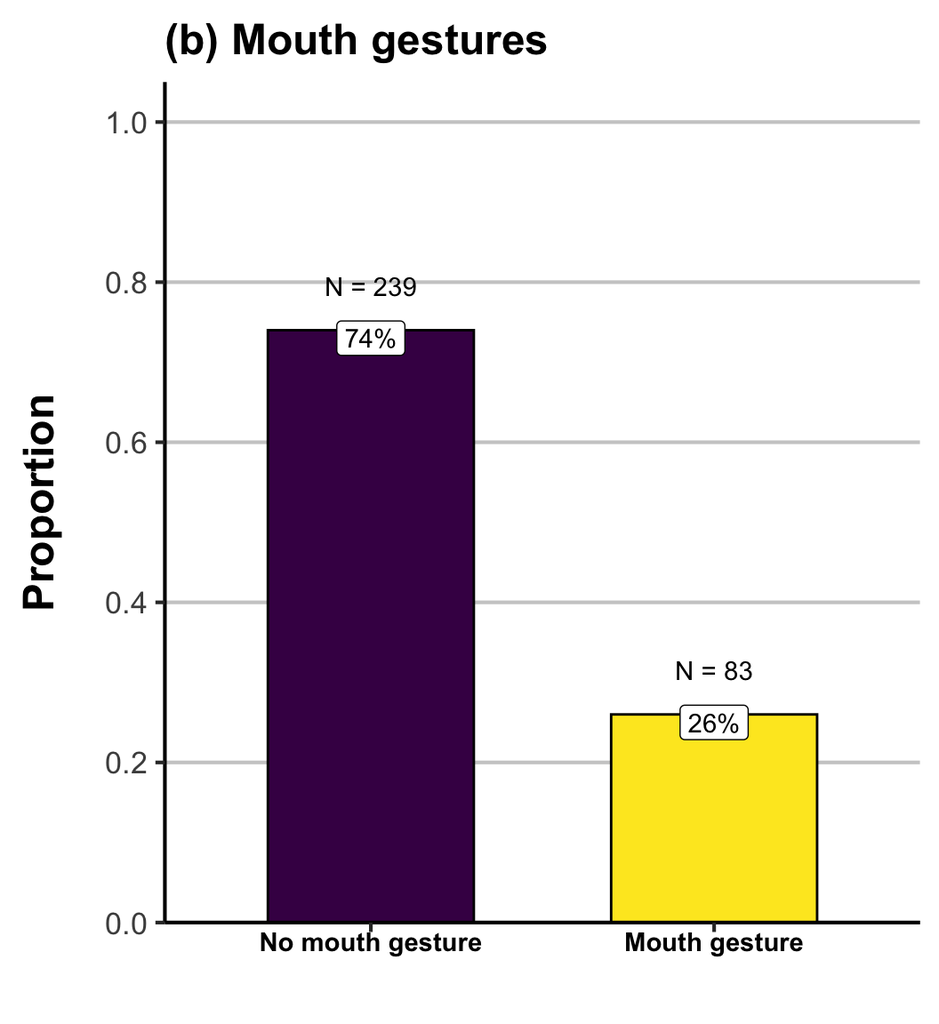

```r
# Data and aesthetics:

Mgesture_p <- neg %>%
  count(MouthGesture_YesNo, sort = TRUE) %>%
  mutate(Proportion = proportion(n),
         Perc = percentage(n),
         N = str_c('N = ', n)) %>%
  ggplot(aes(x = reorder(MouthGesture_YesNo, desc(Proportion)),
             y = Proportion, fill = reorder(MouthGesture_YesNo, desc(Proportion))))

# Add geoms:

Mgesture_p <- Mgesture_p +
  geom_bar(stat = 'identity', col = 'black', width = 0.6) +
  geom_text(aes(label = N), nudge_y = 0.055) +
  geom_label(aes(label = Perc), nudge_y = -0.01, fill = 'white')

# Add other plot features:

Mgesture_p <- Mgesture_p +
  scale_fill_viridis_d() +
  scale_y_continuous(breaks = seq(0, 1.0, 0.2), limits = c(0, 1.05),
                     expand = c(0, 0)) +
  xlab('') +
  ggtitle('(b) Mouth gestures') +
  theme_BSL()

# Plot:

Mgesture_p
```

```r
# Save:

ggsave('../figures/mouth_gesture.pdf', Mgesture_p,
       width = 6.5, height = 5)
ggsave('../figures/mouth_gesture.png', Mgesture_p,
       width = 6.5, height = 5)
```

Gab’s new suggestion (June 28, 2021): Check that the mouth gestures co-occur with manual signs or not.

```r
example_3 <- c('PRESSED-LIPS', 'SYLL:POOH', 'SYLL:SHH')

neg %>%
  filter(MouthGestF_value %in% example_3) %>%
  mutate(Manual = ifelse(N_manual_value == 'Absent', 'no manual', 'manual')) %>%
  count(Manual, MouthGestF_value) %>%
  group_by(MouthGestF_value) %>%
  mutate(prop = n / sum(n))
```

```
## # A tibble: 4 × 4
## # Groups:   MouthGestF_value [3]
##   Manual    MouthGestF_value     n  prop
##   <chr>     <chr>            <int> <dbl>
## 1 manual    PRESSED-LIPS        38 0.717
## 2 manual    SYLL:POOH            9 1
## 3 manual    SYLL:SHH             4 1
## 4 no manual PRESSED-LIPS        15 0.283
```

Only pressed lips occur 28% times (15 instances) without manuals.

Check how many cases was there mouthing and mouth gesture within the same clause:

```r
both <- neg %>%
  filter(MouthGesture_YesNo == 'Mouth gesture',
         MouthingNegation_value != 'Absent')

nrow(both) # 11 cases
```

```
## [1] 11
```

```r
both %>% pull(CLU_value)
```

```
##  [1] "BL07F35WDC_CLU#085"    "BL29F55WDC_LH_CLU#133" "BM10M67WDNC_CLU#035"
##  [4] "BM10M67WDNC_CLU#121"   "BM14F36WHC_CLU#069"    "LN06F44WHC_CLU#124"
##  [7] "LN24M31BHC_LH_CLU#040" "MC01M18WHC_CLU#066"    "MC10M69WHC_CLU#062"
## [10] "MC10M69WHC_CLU#071"    "MC10M69WHC_CLU#086"
```

## Double-plot: Mouthing and mouth gestures

Make a double plot of mouthing and mouth gestures. First, design matrix.

```r
fig_matrix <- matrix(c(1, 1, 1, 1, 1, 2, 2, 2, 2),
                     nrow = 1)
```

Use grid.arrange() to put them both into a plot with the specified matrix.

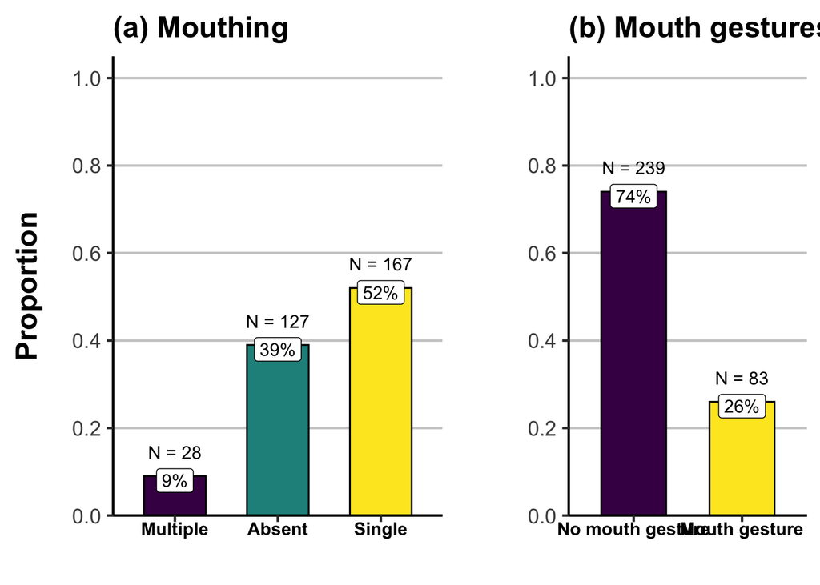

```r
# When included in double plot, we don't need y-axis label for the (c) plot again:

Mgesture_p <- Mgesture_p +
  ylab('')

mouthin_mouth_gesture <- grid.arrange(mouthing_p, Mgesture_p,
                     layout_matrix = fig_matrix)
```

```r
# Save:

ggsave('../figures/mouth_both.pdf', mouthin_mouth_gesture,
       width = 10, height = 5)
ggsave('../figures/mouth_both.png', mouthin_mouth_gesture,
       width = 10, height = 5)
```

## Descriptive stats: Head shakes

Check counts for new HS variable (recoded):

```r
neg %>%
  count(HS_new, sort = TRUE) %>%
  mutate(Perc = percentage(n)) %>%
  print(n = Inf)
```

```
## # A tibble: 7 × 3
##   HS_new                  n Perc
##   <chr>               <int> <chr>
## 1 HS                    160 50%
## 2 NHS, HS                61 19%
## 3 NHS                    40 12%
## 4 HS, NHS                34 11%
## 5 Combination with HS    15 5%
## 6 HS with nod             9 3%
## 7 Nod                     3 1%
```

**Addition October 21, 2022**: Gab requested the `Nod` category to be removed from these counts:

```r
neg %>%
  count(HS_new, sort = TRUE) %>%
  filter(HS_new != 'Nod') %>%
  mutate(Perc = percentage(n)) %>%
  print(n = Inf)
```

```
## # A tibble: 6 × 3
##   HS_new                  n Perc
##   <chr>               <int> <chr>
## 1 HS                    160 50%
## 2 NHS, HS                61 19%
## 3 NHS                    40 13%
## 4 HS, NHS                34 11%
## 5 Combination with HS    15 5%
## 6 HS with nod             9 3%
```

Plot this.

**Addition July 10, 2025**: Reviewer 2 remarked on the floating bars, which we’ll fix now. For that, as above, we’ll also have to create an individual nudge variable.

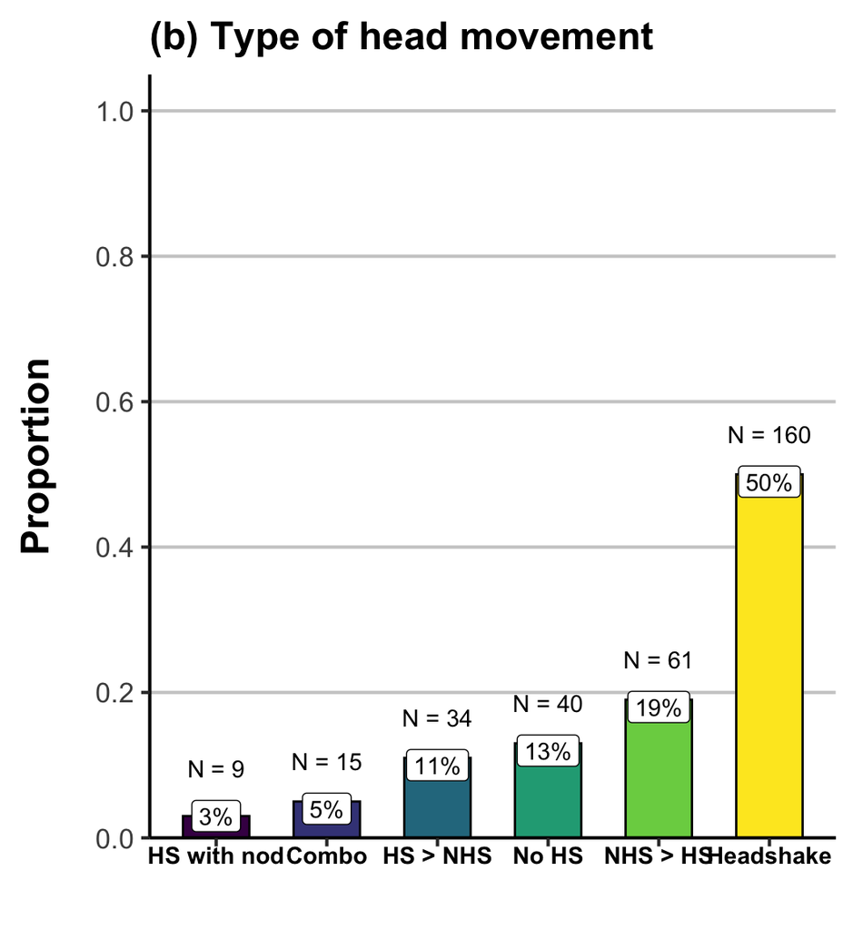

```r
# Data and aesthetics:

HS_p <- neg %>%
  count(HS_new, sort = TRUE) %>%
  filter(HS_new != 'Nod') %>%
  mutate(Proportion = proportion(n),
         Perc = percentage(n),
         N = str_c('N = ', n)) %>%
  mutate(HS_new = ifelse(HS_new == 'HS',
                         'Headshake', HS_new), # renamings for plot
         HS_new = ifelse(HS_new == 'NHS, HS',
                         'NHS > HS', HS_new),
         HS_new = ifelse(HS_new == 'HS, NHS',
                         'HS > NHS', HS_new),
         HS_new = ifelse(HS_new == 'Combination with HS',
                         'Combo', HS_new),
         HS_new = ifelse(HS_new == 'NHS',
                         'No HS', HS_new),
         label_nudges = rev(c(0, -0.01, -0.01, -0.01, -0.01, -0.01)),
         text_nudges = rev(c(0.055 + 0.01, 0.055, 0.055, 0.055, 0.055, 0.055))) %>%
  ggplot(aes(x = reorder(HS_new, Proportion),
             y = Proportion, fill = reorder(HS_new, Proportion)))

# Add geoms:

HS_p <- HS_p +
  geom_bar(stat = 'identity', col = 'black', width = 0.6) +
  geom_text(aes(label = N, y = Proportion + text_nudges)) +
  geom_label(aes(label = Perc, y = Proportion + label_nudges), fill = 'white')

# Add other plot features:

HS_p <- HS_p +
  scale_fill_viridis_d() +
  scale_y_continuous(breaks = seq(0, 1.0, 0.2), limits = c(0, 1.05),
                     expand = c(0, 0)) +
  xlab('') +
  ggtitle('(b) Type of head movement') +
  theme_BSL()

# Plot:

HS_p
```

```r
# Save:

ggsave('../figures/headshake_detailed.pdf', HS_p,
       width = 6.5, height = 5)
ggsave('../figures/headshake_detailed.png', HS_p,
       width = 6.5, height = 5)
```

Get the counts of HS yes /no variable:

```r
neg %>%
  filter(HS_new != 'Nod') %>%
  count(HS_YesNo, sort = TRUE) %>%
  mutate(Perc = percentage(n))
```

```
## # A tibble: 2 × 3
##   HS_YesNo     n Perc
##   <chr>    <int> <chr>
## 1 HS         279 87%
## 2 no HS       40 13%
```

Make the corresponding plot:

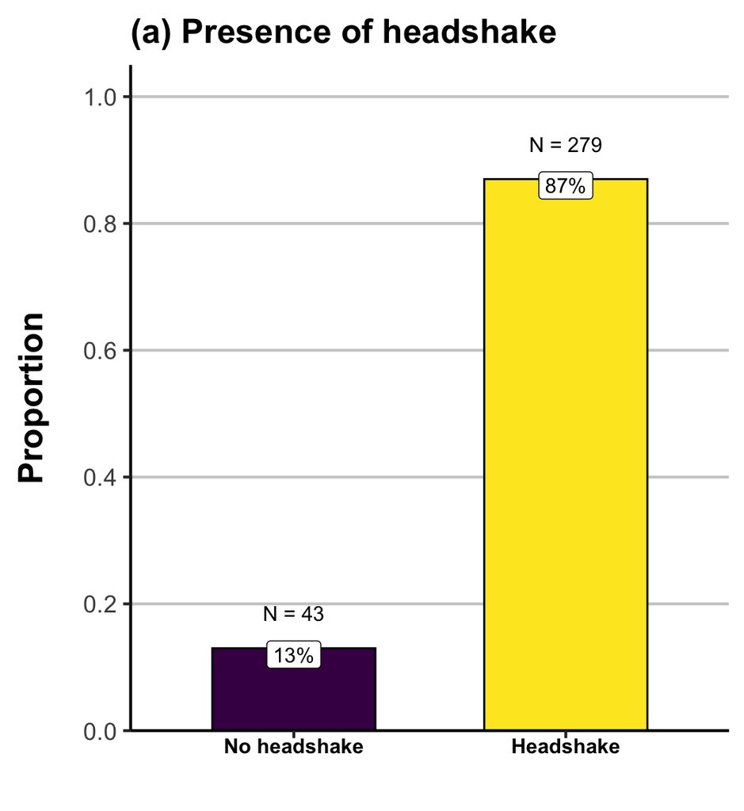

```r
# Data and aesthetics:

HS_YesNo_p <- neg %>%
  count(HS_YesNo, sort = TRUE) %>%
  mutate(HS_YesNo = ifelse(HS_YesNo == 'HS', 'Headshake', 'No headshake')) %>%
  mutate(Proportion = proportion(n),
         Perc = percentage(n),
         N = str_c('N = ', n)) %>%
  ggplot(aes(x = reorder(HS_YesNo, Proportion),
             y = Proportion, fill = reorder(HS_YesNo, Proportion)))

# Add geoms:

HS_YesNo_p <- HS_YesNo_p +
  geom_bar(stat = 'identity', col = 'black', width = 0.6) +
  geom_text(aes(label = N), nudge_y = 0.055) +
  geom_label(aes(label = Perc), nudge_y = -0.01, fill = 'white')

# Add other plot features:

HS_YesNo_p <- HS_YesNo_p +
  scale_fill_viridis_d() +
  scale_y_continuous(breaks = seq(0, 1.0, 0.2), limits = c(0, 1.05),
                     expand = c(0, 0)) +
  xlab('') +
  ggtitle('(a) Presence of headshake') +
  theme_BSL()

# Plot:

HS_YesNo_p
```

```r
# Save:

ggsave('../figures/headshake_YesNo.pdf', HS_YesNo_p,
       width = 6.5, height = 5)
ggsave('../figures/headshake_YesNo.png', HS_YesNo_p,
       width = 6.5, height = 5)
```

```r
fig3_matrix <- matrix(c(1, 1, 1, 1, 1, 2, 2, 2, 2, 2, 2, 2, 2, 2),
                      nrow = 1)
```

Use grid.arrange() to put them both into a plot with the specified matrix.

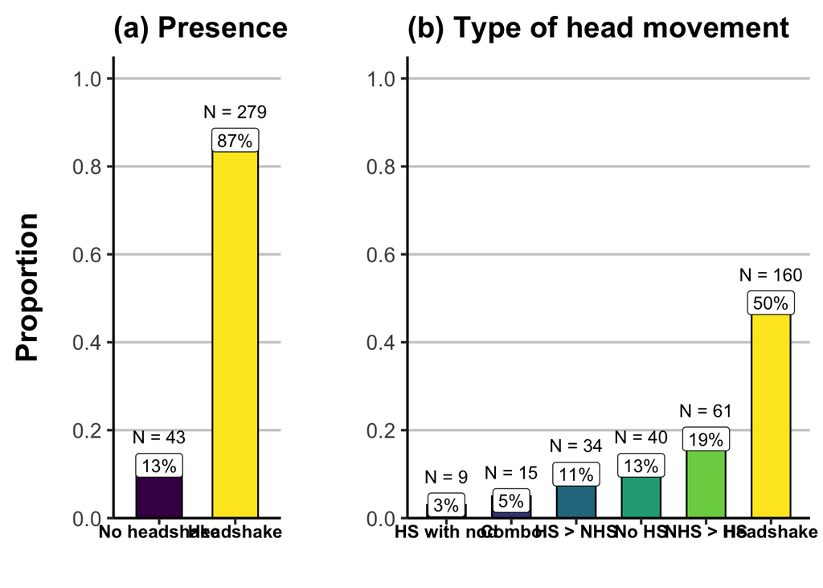

```r
# When included in double plot, we don't need y-axis label for the (b) plot again:

HS_p <- HS_p +
  ylab('')

fig3 <- grid.arrange(HS_YesNo_p, HS_p,
                     layout_matrix = fig3_matrix)
```

```r
# Save:

ggsave('../figures/both_headshakes.pdf', fig3,
       width = 12, height = 5)
ggsave('../figures/both_headshakes.png', fig3,
       width = 12, height = 5)
```

## Combinations of signalling strategies

Tabulate combinations of the four form variables.

```r
neg %>% count(FormSum) %>%
  mutate(Perc = percentage(n))
```

```
## # A tibble: 4 × 3
##   FormSum     n Perc
##     <dbl> <int> <chr>
## 1       1    42 13%
## 2       2    99 31%
## 3       3   174 54%
## 4       4     7 2%
```

Check what combinations they are:

```r
neg <- mutate(neg,
              StrategyCombo = str_c(Manual_YesNo, ' + ',
                                    Mouthing_YesNo, ' + ',
                                    MouthGesture_YesNo, ' + ',
                                    HS_YesNo))
```

Count:

```r
# 4 strategies

neg %>% filter(FormSum == 4) %>%
  count(StrategyCombo, sort = TRUE)
```

```
## # A tibble: 1 × 2
##   StrategyCombo                                   n
##   <chr>                                       <int>
## 1 manual sign + mouthing + Mouth gesture + HS     7
```

```r
# 3 strategies

neg %>% filter(FormSum == 3) %>%
  count(StrategyCombo, sort = TRUE)
```

```
## # A tibble: 4 × 2
##   StrategyCombo                                      n
##   <chr>                                          <int>
## 1 manual sign + mouthing + No mouth gesture + HS   120
## 2 manual sign + no mouthing + Mouth gesture + HS    50
## 3 no manual sign + mouthing + Mouth gesture + HS     3
## 4 manual sign + mouthing + Mouth gesture + no HS     1
```

```r
# 2 strategies

neg %>% filter(FormSum == 2) %>%
  count(StrategyCombo, sort = TRUE)
```

```
## # A tibble: 5 × 2
##   StrategyCombo                                         n
##   <chr>                                             <int>
## 1 no manual sign + mouthing + No mouth gesture + HS    34
## 2 manual sign + mouthing + No mouth gesture + no HS    25
## 3 manual sign + no mouthing + No mouth gesture + HS    18
## 4 no manual sign + no mouthing + Mouth gesture + HS    15
## 5 manual sign + no mouthing + Mouth gesture + no HS     7
```

```r
# 1 strategies

neg %>% filter(FormSum == 1) %>%
  count(StrategyCombo, sort = TRUE)
```

```
## # A tibble: 3 × 2
##   StrategyCombo                                            n
##   <chr>                                                <int>
## 1 no manual sign + no mouthing + No mouth gesture + HS    32
## 2 manual sign + no mouthing + No mouth gesture + no HS     5
## 3 no manual sign + mouthing + No mouth gesture + no HS     5
```

Check those that have more than one encoding strategy:

```r
neg %>%
  filter(FormSum != 0) %>%
  mutate(Multi_YesNo = ifelse(FormSum > 1, 'multiple', 'single')) %>%
  count(Multi_YesNo) %>%
  mutate(Perc = percentage(n))
```

```
## # A tibble: 2 × 3
##   Multi_YesNo     n Perc
##   <chr>       <int> <chr>
## 1 multiple      280 87%
## 2 single         42 13%
```

Make a plot of the number of encoding strategies:

** Bodo Winter, Update July 10, 2025:** Need to fix y-axis label here too and then adjust nudges for labels.

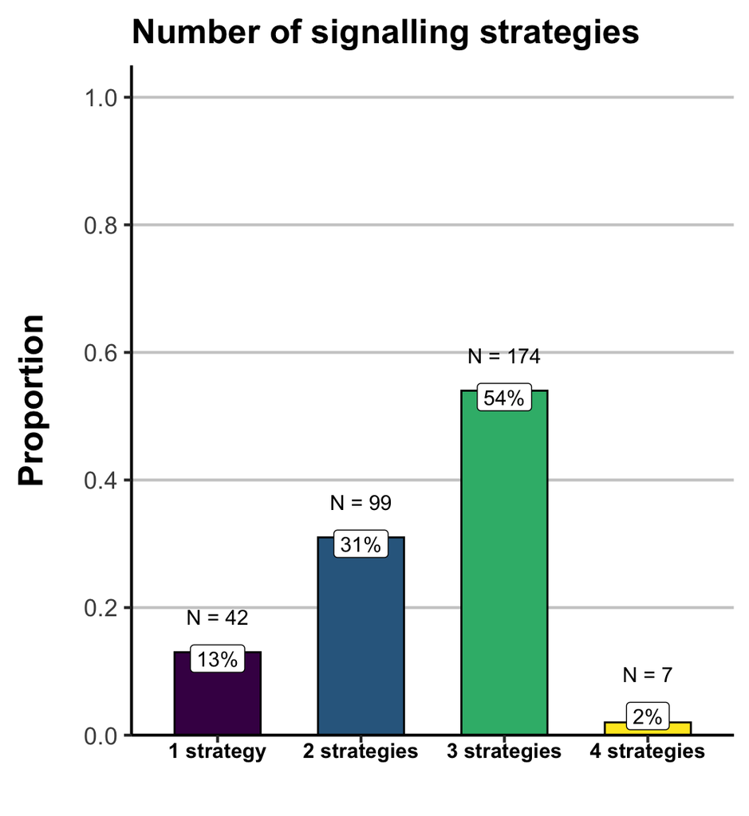

```r
# Data and aesthetics:

strat_p <- neg %>%
  filter(FormSum != 0) %>%
  count(FormSum, sort = FALSE) %>%
  mutate(Proportion = proportion(n),
         Perc = percentage(n),
         N = str_c('N = ', n)) %>%
  mutate(FormSum = ifelse(FormSum == 1, '1 strategy', FormSum), # renamings for plot
         FormSum = ifelse(FormSum == 2, '2 strategies', FormSum),
         FormSum = ifelse(FormSum == 3, '3 strategies', FormSum),
         FormSum = ifelse(FormSum == 4, '4 strategies', FormSum),
         nudge_labels = c(-0.01, -0.01, -0.01, 0.01),
         nudge_text = c(0.055, 0.055, 0.055, 0.055 + 0.02)) %>%
  ggplot(aes(x = FormSum,
             y = Proportion, fill = FormSum, Proportion))

# Add geoms:

strat_p <- strat_p +
  geom_bar(stat = 'identity', col = 'black', width = 0.6) +
  geom_text(aes(label = N, y = Proportion + nudge_text)) +
  geom_label(aes(label = Perc, y = Proportion + nudge_labels), fill = 'white')

# Add other plot features:

strat_p <- strat_p +
  scale_fill_viridis_d() +
  scale_y_continuous(breaks = seq(0, 1.0, 0.2), limits = c(0, 1.05),
                     expand = c(0, 0)) +
  xlab('') +
  ggtitle('Number of signalling strategies') +
  theme_BSL()

# Plot:

strat_p
```

```r
# Save:

ggsave('../figures/strategy_count.pdf', strat_p,
       width = 6.5, height = 5)
ggsave('../figures/strategy_count.png', strat_p,
       width = 6.5, height = 5)
```

Find those cases (single or complex clauses) for which the *only* strategy is mouthing.

```r
# How many?

filter(neg, FormSum == 1) %>% count(Mouthing_YesNo)
```

```
## # A tibble: 2 × 2
##   Mouthing_YesNo     n
##   <chr>          <int>
## 1 mouthing           5
## 2 no mouthing       37
```

```r
# Which ones?

filter(neg,
       FormSum == 1, Mouthing_YesNo == 'mouthing') %>%
  select(CLU_value, Mouthing_value)
```

```
## # A tibble: 5 × 2
##   CLU_value          Mouthing_value
##   <chr>              <chr>
## 1 BL04M74WHC_CLU#133 no money
## 2 BL30M65WDC_CLU#098 Annette, not allowed
## 3 BM22F36WDC_CLU#103 can't remem(ber), who
## 4 LN04F41WHC_CLU#109 not fit
## 5 MC28M26WDC_CLU#096 don't know
```

## Comparison to patterns for complex clauses

This section looks at the extent to which the patterns for complex clauses are different. This will be done by means of Chi-square tests. We will collate compl and neg into “both”, with an identifier variable. But first we need to get rid of SharedC echo, fragments, and uncertain identifications. (Update June 30, 2021; based on Gab’s most recent emails explaining that complex should only be “embed”, “depend”, or any combination of the two):

```r
compl_subset <- filter(compl,
                       CLU_simplified %in% c('Combination', 'Depend', 'Embed'))

both <- bind_rows(neg, compl_subset)
both$ClauseType <- c(rep('Single', nrow(neg)),
                     rep('Complex', nrow(compl_subset)))
```

Check effect sizes (for the interaction between clause type with all variables):

```r
# Negation function:

with(both,
     cramersV(table(N_function_value, ClauseType)))
```

```
## [1] 0.1765767
```

```r
# Check what this is:

with(both,
     table(N_function_value, ClauseType))
```

```
##                    ClauseType
## N_function_value    Complex Single
##   Neg/alternative         1      3
##   Neg/declarative        47    170
##   Neg/imperative          1      7
##   Neg/interrogative       0     15
##   Neg/reprise             1     12
##   Neg/response           13    115
```

```r
round(with(both,
           chisq.test(table(N_function_value, ClauseType))$stdres), 1)
```

```
##                    ClauseType
## N_function_value    Complex Single
##   Neg/alternative       0.5   -0.5
##   Neg/declarative       3.2   -3.2
##   Neg/imperative       -0.3    0.3
##   Neg/interrogative    -1.7    1.7
##   Neg/reprise          -0.9    0.9
##   Neg/response         -2.3    2.3
```

```r
# Manual negation:

with(both,
     cramersV(table(N_manual_value, ClauseType)))
```

```
## [1] 0.08935183
```

```r
# Non-Manual negation:

with(both,
     cramersV(table(N_nonmanual_value, ClauseType)))
```

```
## [1] 7.51072e-17
```

```r
# Negation in mouthing:

with(both,
     cramersV(table(MouthingNegation_value, ClauseType)))
```

```
## [1] 0.1379526
```

```r
# Check what this is (mouthing):

with(both,
     table(MouthingNegation_value, ClauseType))
```

```
##                       ClauseType
## MouthingNegation_value Complex Single
##               Absent        19    127
##               Multiple       1     28
##               Single        43    167
```

```r
round(with(both,
           chisq.test(table(MouthingNegation_value, ClauseType))$stdres), 1)
```

```
##                       ClauseType
## MouthingNegation_value Complex Single
##               Absent      -1.4    1.4
##               Multiple    -2.0    2.0
##               Single       2.4   -2.4
```

```r
# Mouth gestures:

with(both,
     cramersV(table(MouthGesture_YesNo, ClauseType)))
```

```
## [1] 0.06344352
```

```r
# Head shaking:

with(both,
     cramersV(table(HS_new, ClauseType)))
```

```
## [1] 0.1007985
```

```r
# Head shaking:

both <- mutate(both,
               HS_YesNo = ifelse(HS_YesNo == 'Any\nhead shake', 'HS', HS_YesNo),
               HS_YesNo = ifelse(HS_YesNo == 'No\nhead shake', 'no HS', HS_YesNo))
with(both,
     cramersV(table(HS_YesNo, ClauseType)))
```

```
## [1] 0.01424045
```

```r
# Multi-strategy count:

with(both,
     cramersV(table(FormSum, ClauseType)))
```

```
## [1] 0.07689487
```

Get the counts for the different variables. Function of negation:

```r
compl_subset %>%
  count(N_function_value, sort = TRUE) %>%
  filter(!is.na(N_function_value)) %>%
  mutate(Perc = percentage(n))
```

```
## # A tibble: 5 × 3
##   N_function_value     n Perc
##   <chr>            <int> <chr>
## 1 Neg/declarative     47 75%
## 2 Neg/response        13 21%
## 3 Neg/alternative      1 2%
## 4 Neg/imperative       1 2%
## 5 Neg/reprise          1 2%
```

Manual negation signs:

```r
compl_subset %>%
  count(N_manual_value, sort = TRUE) %>%
  mutate(Perc = percentage(n))
```

```
## # A tibble: 3 × 3
##   N_manual_value     n Perc
##   <chr>          <int> <chr>
## 1 Single            44 70%
## 2 Absent            16 25%
## 3 Multiple           3 5%
```

Non-manual:

```r
compl_subset %>%
  count(N_nonmanual_value , sort = TRUE) %>%
  mutate(Perc = percentage(n))
```

```
## # A tibble: 2 × 3
##   N_nonmanual_value     n Perc
##   <chr>             <int> <chr>
## 1 Present              62 98%
## 2 Absent                1 2%
```

Negation in mouthing:

```r
compl_subset %>%
  count(MouthingNegation_value, sort = TRUE) %>%
  mutate(Perc = percentage(n))
```

```
## # A tibble: 3 × 3
##   MouthingNegation_value     n Perc
##   <chr>                  <int> <chr>
## 1 Single                    43 68%
## 2 Absent                    19 30%
## 3 Multiple                   1 2%
```

Mouth gestures:

```r
compl_subset %>%
  count(MouthGesture_YesNo, sort = TRUE) %>%
  mutate(Perc = percentage(n))
```

```
## # A tibble: 2 × 3
##   MouthGesture_YesNo     n Perc
##   <chr>              <int> <chr>
## 1 No mouth gesture      52 83%
## 2 Mouth gesture         11 17%
```

Head shaking:

```r
compl_subset %>%
  count(HS, sort = TRUE) %>%
  mutate(Perc = percentage(n)) %>% print(n = Inf)
```

```
## # A tibble: 10 × 3
##    HS                         n Perc
##    <chr>                  <int> <chr>
##  1 HS                        25 40%
##  2 NHS, HS                   17 27%
##  3 NHS                        7 11%
##  4 HS, NHS                    4 6%
##  5 HS1                        3 5%
##  6 HS1, NHS                   3 5%
##  7 NHS, HS+Nod                1 2%
##  8 NHS, HS, NHS               1 2%
##  9 NHS, HS, NHS, HS1, NHS     1 2%
## 10 NHS, HS1                   1 2%
```

Head shaking:

```r
compl_subset %>%
  count(HS_YesNo, sort = TRUE) %>%
  mutate(Perc = percentage(n)) %>% print(n = Inf)
```

```
## # A tibble: 2 × 3
##   HS_YesNo     n Perc
##   <chr>    <int> <chr>
## 1 HS          56 89%
## 2 no HS        7 11%
```

Strategy count:

```r
compl_subset %>%
  count(FormSum, sort = TRUE) %>%
  mutate(Perc = percentage(n)) %>% print(n = Inf)
```

```
## # A tibble: 3 × 3
##   FormSum     n Perc
##     <dbl> <int> <chr>
## 1       3    38 60%
## 2       2    19 30%
## 3       1     6 10%
```

## Individual variation across the variables

Get a data frame with only those that have at least 10 data points:

```r
above_10s <- both %>%
  count(Participant) %>%
  filter(n > 10) %>%
  pull(Participant)

length(above_10s)
```

```
## [1] 16
```

```r
neg_10 <- filter(both,
                 Participant %in% above_10s)
```

How many tokens are this?

```r
nrow(neg_10)
```

```
## [1] 224
```

Check manual signs for negation per participant:

```r
ppt_manual_tab <- with(neg_10, table(Participant, N_manual_value))

# Check:

rowprop_tab(ppt_manual_tab)
```

```
##            N_manual_value
## Participant Absent Multiple Single
##        BL07   0.45     0.00   0.55
##        BL08   0.13     0.00   0.87
##        BL09   0.29     0.06   0.65
##        BL30   0.46     0.00   0.54
##        BM07   0.18     0.09   0.73
##        BM10   0.17     0.17   0.67
##        BM13   0.17     0.08   0.75
##        BM21   0.45     0.18   0.36
##        LN03   0.45     0.18   0.36
##        LN04   0.33     0.06   0.61
##        LN05   0.47     0.00   0.53
##        LN06   0.50     0.00   0.50
##        LN11   0.19     0.12   0.69
##        LN25   0.07     0.14   0.79
##        MC01   0.06     0.06   0.88
##        MC22   0.17     0.06   0.78
```

```r
# Which max:

table(apply(ppt_manual_tab, MARGIN = 1,
            FUN = function(x) colnames(ppt_manual_tab)[which.max(x)]))
```

```
##
## Absent Single
##      3     13
```

```r
# Which max percentage:

prop_tab(table(apply(ppt_manual_tab, MARGIN = 1,
                     FUN = function(x) colnames(ppt_manual_tab)[which.max(x)])))
```

```
##
## Absent Single
##   0.19   0.81
```

**New addition October 21/10/2021**: Regularity per participant:

```r
neg_10_reg <- filter(neg_10, Manual_YesNo == 'manual sign')
ppt_regularity_tab <- with(neg_10_reg, table(Participant, regularity))

# Check:

rowprop_tab(ppt_regularity_tab)
```

```
##            regularity
## Participant    ? Irregular Regular
##        BL07 0.00      0.33    0.67
##        BL08 0.00      0.46    0.54
##        BL09 0.17      0.42    0.42
##        BL30 0.00      0.14    0.86
##        BM07 0.11      0.67    0.22
##        BM10 0.10      0.60    0.30
##        BM13 0.00      0.40    0.60
##        BM21 0.00      0.00    1.00
##        LN03 0.00      0.33    0.67
##        LN04 0.00      0.50    0.50
##        LN05 0.00      0.12    0.88
##        LN06 0.00      0.57    0.43
##        LN11 0.00      0.23    0.77
##        LN25 0.23      0.15    0.62
##        MC01 0.00      0.27    0.73
##        MC22 0.27      0.33    0.40
```

```r
# Which max:

table(apply(ppt_regularity_tab, MARGIN = 1,
            FUN = function(x) colnames(ppt_regularity_tab)[which.max(x)]))
```

```
##
## Irregular   Regular
##         5        11
```

```r
# Which max percentage:

prop_tab(table(apply(ppt_regularity_tab, MARGIN = 1,
                     FUN = function(x) colnames(ppt_regularity_tab)[which.max(x)])))
```

```
##
## Irregular   Regular
##      0.31      0.69
```

Check manual versus non-manual per participant:

```r
ppt_nonmanual_tab <- with(neg_10, table(Participant, N_nonmanual_value))

# Check:

rowprop_tab(ppt_nonmanual_tab)
```

```
##            N_nonmanual_value
## Participant Absent Present
##        BL07   0.09    0.91
##        BL08   0.07    0.93
##        BL09   0.00    1.00
##        BL30   0.00    1.00
##        BM07   0.00    1.00
##        BM10   0.08    0.92
##        BM13   0.00    1.00
##        BM21   0.00    1.00
##        LN03   0.00    1.00
##        LN04   0.00    1.00
##        LN05   0.00    1.00
##        LN06   0.00    1.00
##        LN11   0.06    0.94
##        LN25   0.07    0.93
##        MC01   0.00    1.00
##        MC22   0.00    1.00
```

```r
# Check average proportion:

mean(rowprop_tab(ppt_nonmanual_tab)[, 'Present'])
```

```
## [1] 0.976875
```

```r
# Which max:

table(apply(ppt_nonmanual_tab, MARGIN = 1,
            FUN = function(x) colnames(ppt_nonmanual_tab)[which.max(x)]))
```

```
##
## Present
##      16
```

```r
# Which max percentage:

prop_tab(table(apply(ppt_nonmanual_tab, MARGIN = 1,
                     FUN = function(x) colnames(ppt_nonmanual_tab)[which.max(x)])))
```

```
##
## Present
##       1
```

Check mouthing per participant:

```r
ppt_mouthing_tab <- with(neg_10, table(Participant, MouthingNegation_value))

# Check:

rowprop_tab(ppt_mouthing_tab)
```

```
##            MouthingNegation_value
## Participant Absent Multiple Single
##        BL07   0.27     0.09   0.64
##        BL08   0.27     0.07   0.67
##        BL09   0.65     0.06   0.29
##        BL30   0.23     0.08   0.69
##        BM07   0.82     0.00   0.18
##        BM10   0.25     0.08   0.67
##        BM13   0.17     0.17   0.67
##        BM21   0.55     0.00   0.45
##        LN03   0.36     0.09   0.55
##        LN04   0.28     0.00   0.72
##        LN05   0.67     0.00   0.33
##        LN06   0.50     0.00   0.50
##        LN11   0.50     0.00   0.50
##        LN25   0.29     0.14   0.57
##        MC01   0.31     0.00   0.69
##        MC22   0.17     0.28   0.56
```

```r
# Which max:

table(apply(ppt_mouthing_tab, MARGIN = 1,
            FUN = function(x) colnames(ppt_mouthing_tab)[which.max(x)]))
```

```
##
## Absent Single
##      6     10
```

```r
# Percentage:

prop_tab(table(apply(ppt_mouthing_tab, MARGIN = 1,
                     FUN = function(x) colnames(ppt_mouthing_tab)[which.max(x)])))
```

```
##
## Absent Single
##   0.38   0.62
```

Check mouth gesture per participant:

```r
ppt_mouthgesture_tab <- with(neg_10, table(Participant, MouthGesture_YesNo))

# Check:

rowprop_tab(ppt_mouthgesture_tab)
```

```
##            MouthGesture_YesNo
## Participant Mouth gesture No mouth gesture
##        BL07          0.18             0.82
##        BL08          0.07             0.93
##        BL09          0.59             0.41
##        BL30          0.15             0.85
##        BM07          0.27             0.73
##        BM10          0.33             0.67
##        BM13          0.08             0.92
##        BM21          0.27             0.73
##        LN03          0.09             0.91
##        LN04          0.17             0.83
##        LN05          0.27             0.73
##        LN06          0.36             0.64
##        LN11          0.31             0.69
##        LN25          0.21             0.79
##        MC01          0.38             0.62
##        MC22          0.11             0.89
```

```r
# Which max:

table(apply(ppt_mouthgesture_tab, MARGIN = 1,
            FUN = function(x) colnames(ppt_mouthgesture_tab)[which.max(x)]))
```

```
##
##    Mouth gesture No mouth gesture
##                1               15
```

```r
# Percentage:

prop_tab(table(apply(ppt_mouthgesture_tab, MARGIN = 1,
                     FUN = function(x) colnames(ppt_mouthgesture_tab)[which.max(x)])))
```

```
##
##    Mouth gesture No mouth gesture
##             0.06             0.94
```

Check head shake per participant:

```r
ppt_HS_tab <- with(neg_10, table(Participant, HS_YesNo))

# Check:

rowprop_tab(ppt_HS_tab)
```

```
##            HS_YesNo
## Participant   HS no HS
##        BL07 0.91  0.09
##        BL08 0.87  0.13
##        BL09 1.00  0.00
##        BL30 0.92  0.08
##        BM07 1.00  0.00
##        BM10 0.83  0.17
##        BM13 0.83  0.17
##        BM21 1.00  0.00
##        LN03 0.82  0.18
##        LN04 0.89  0.11
##        LN05 1.00  0.00
##        LN06 1.00  0.00
##        LN11 0.75  0.25
##        LN25 0.64  0.36
##        MC01 1.00  0.00
##        MC22 0.78  0.22
```

```r
# What is the average?

mean(rowprop_tab(ppt_HS_tab)[, 'HS'])
```

```
## [1] 0.89
```

```r
# Which max:

table(apply(ppt_HS_tab, MARGIN = 1,
            FUN = function(x) colnames(ppt_HS_tab)[which.max(x)]))
```

```
##
## HS
## 16
```

```r
# Percentage:

prop_tab(table(apply(ppt_HS_tab, MARGIN = 1,
                     FUN = function(x) colnames(ppt_HS_tab)[which.max(x)])))
```

```
##
## HS
##  1
```

```r
ppt_strategy_tab <- with(neg_10, table(Participant, FormSum))

# Check:

rowprop_tab(ppt_strategy_tab)
```

```
##            FormSum
## Participant    1    2    3    4
##        BL07 0.18 0.27 0.55 0.00
##        BL08 0.07 0.33 0.60 0.00
##        BL09 0.06 0.24 0.71 0.00
##        BL30 0.15 0.31 0.54 0.00
##        BM07 0.18 0.36 0.45 0.00
##        BM10 0.00 0.33 0.58 0.08
##        BM13 0.00 0.42 0.58 0.00
##        BM21 0.27 0.18 0.55 0.00
##        LN03 0.27 0.36 0.36 0.00
##        LN04 0.17 0.22 0.61 0.00
##        LN05 0.27 0.33 0.40 0.00
##        LN06 0.21 0.29 0.43 0.07
##        LN11 0.12 0.38 0.50 0.00
##        LN25 0.07 0.36 0.57 0.00
##        MC01 0.00 0.06 0.88 0.06
##        MC22 0.06 0.33 0.61 0.00
```

```r
# Which max:

table(apply(ppt_strategy_tab, MARGIN = 1,
            FUN = function(x) colnames(ppt_strategy_tab)[which.max(x)]))
```

```
##
##  2  3
##  1 15
```

```r
# Percentage:

prop_tab(table(apply(ppt_strategy_tab, MARGIN = 1,
                     FUN = function(x) colnames(ppt_strategy_tab)[which.max(x)])))
```

```
##
##    2    3
## 0.06 0.94
```

## Form and function

First, let’s look at manual signaling.

```r
# Function type:

with(both,
     cramersV(table(Manual_YesNo, N_function_value)))
```

```
## [1] 0.1509901
```

```r
round(with(both,
           chisq.test(table(Manual_YesNo, N_function_value))$stdres), 2)
```

```
##                 N_function_value
## Manual_YesNo     Neg/alternative Neg/declarative Neg/imperative
##   manual sign               1.23           -0.88          -0.66
##   no manual sign           -1.23            0.88           0.66
##                 N_function_value
## Manual_YesNo     Neg/interrogative Neg/reprise Neg/response
##   manual sign                 1.24        2.25        -0.51
##   no manual sign             -1.24       -2.25         0.51
```

Second, mouthing:

```r
round(with(neg,
           chisq.test(table(Mouthing_YesNo, N_function_value))$stdres), 2)
```

```
##               N_function_value
## Mouthing_YesNo Neg/alternative Neg/declarative Neg/imperative Neg/interrogative
##    mouthing              -2.16            0.92           1.38             -0.05
##    no mouthing            2.16           -0.92          -1.38              0.05
##               N_function_value
## Mouthing_YesNo Neg/reprise Neg/response
##    mouthing          -0.16        -0.87
##    no mouthing        0.16         0.87
```

Third, mouth gestures:

```r
round(with(neg,
           chisq.test(table(MouthGesture_YesNo, N_function_value))$stdres), 2)
```

```
##                   N_function_value
## MouthGesture_YesNo Neg/alternative Neg/declarative Neg/imperative
##   Mouth gesture               1.63           -0.21          -0.70
##   No mouth gesture           -1.63            0.21           0.70
##                   N_function_value
## MouthGesture_YesNo Neg/interrogative Neg/reprise Neg/response
##   Mouth gesture                -0.52        1.28        -0.17
##   No mouth gesture              0.52       -1.28         0.17
```

Fourth, head shakes:

```r
round(with(neg,
           chisq.test(table(HS_YesNo, N_function_value))$stdres), 2)
```

```
##         N_function_value
## HS_YesNo Neg/alternative Neg/declarative Neg/imperative Neg/interrogative
##    HS               0.68           -1.41          -1.20              0.00
##    no HS           -0.68            1.41           1.20              0.00
##         N_function_value
## HS_YesNo Neg/reprise Neg/response
##    HS           1.39         1.15
##    no HS       -1.39        -1.15
```

Fifth, strategy count:

```r
round(with(neg,
           chisq.test(table(FormSum, N_function_value))$stdres), 2)
```

```
##        N_function_value
## FormSum Neg/alternative Neg/declarative Neg/imperative Neg/interrogative
##       1           -0.67            0.27           0.10              0.82
##       2            0.10            0.66           0.70             -0.92
##       3            0.44           -0.87          -0.60             -0.59
##       4           -0.26            0.23          -0.40              3.04
##        N_function_value
## FormSum Neg/reprise Neg/response
##       1       -1.37         0.00
##       2       -2.35         0.41
##       3        3.26        -0.03
##       4       -0.53        -1.20
```

## Descriptive stats: CLU complex

Check:

```r
compl_subset %>%
  count(CLUcomplex_value, sort = TRUE) %>%
  mutate(Perc = percentage(n))
```

```
## # A tibble: 3 × 3
##   CLUcomplex_value     n Perc
##   <chr>            <int> <chr>
## 1 <NA>                25 40%
## 2 dependent           20 32%
## 3 independent         18 29%
```

## Descriptive stats: CLU within CLU

Check counts:

```r
compl_subset %>%
  count(CLUwithinCLU_value, sort = TRUE) %>%
  mutate(Perc = percentage(n))
```

```
## # A tibble: 8 × 3
##   CLUwithinCLU_value                         n Perc
##   <chr>                                  <int> <chr>
## 1 <NA>                                      32 51%
## 2 contained                                 21 33%
## 3 post-container                             4 6%
## 4 pre-container                              2 3%
## 5 contained+contained                        1 2%
## 6 contained+pre-container                    1 2%
## 7 pre-container, contained                   1 2%
## 8 pre-container, contained+pre-container     1 2%
```

How many are NAs versus something else:

```r
compl_subset %>%
  mutate(NoCLU = ifelse(is.na(CLUwithinCLU_value),
                        'not defined', 'some type of CLU within')) %>%
  count(NoCLU) %>%
  mutate(Perc = percentage(n))
```

```
## # A tibble: 2 × 3
##   NoCLU                       n Perc
##   <chr>                   <int> <chr>
## 1 not defined                32 51%
## 2 some type of CLU within    31 49%
```

Most of these are “Embed” type:

```r
table(compl_subset$CLUcomposite_value, compl_subset$CLUwithinCLU_value)
```

```
##
##               contained contained+contained contained+pre-container
##   Depend              0                   0                       0
##   DependEmbed         0                   0                       0
##   Embed              15                   0                       0
##   EmbedDepend         6                   1                       0
##   EmbedEmbed          0                   0                       1
##
##               post-container pre-container pre-container, contained
##   Depend                   0             0                        0
##   DependEmbed              0             0                        0
##   Embed                    4             1                        1
##   EmbedDepend              0             0                        0
##   EmbedEmbed               0             1                        0
##
##               pre-container, contained+pre-container
##   Depend                                           0
##   DependEmbed                                      0
##   Embed                                            0
##   EmbedDepend                                      0
##   EmbedEmbed                                       1
```

Count this:

```r
compl_subset %>%
  count(CLUwithin_simple, sort = TRUE) %>%
  filter(!is.na(CLUwithin_simple)) %>%
  mutate(Perc = percentage(n))
```

```
## # A tibble: 4 × 3
##   CLUwithin_simple     n Perc
##   <chr>            <int> <chr>
## 1 Contained           22 71%
## 2 Post-container       4 13%
## 3 Combination          3 10%
## 4 Pre-container        2 6%
```

Make a plot of this:

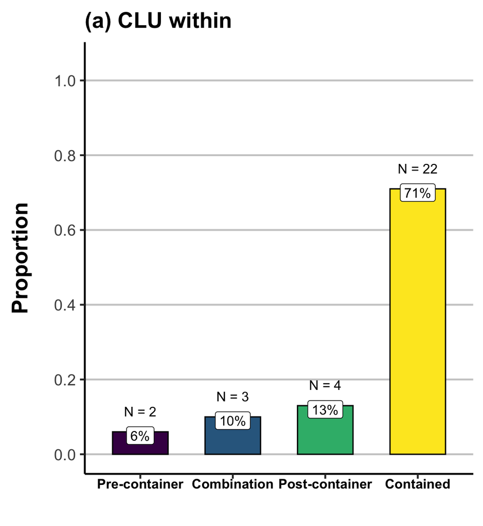

```r
# Data and aesthetics:

within_p <- compl_subset %>%
  count(CLUwithin_simple, sort = TRUE) %>%
  filter(!is.na(CLUwithin_simple)) %>%
  mutate(Proportion = proportion(n),
         Perc = percentage(n),
         N = str_c('N = ', n)) %>%
  ggplot(aes(x = reorder(CLUwithin_simple, Proportion),
             y = Proportion, fill = reorder(CLUwithin_simple, Proportion)))

# Add geoms:

within_p <- within_p +
  geom_bar(stat = 'identity', col = 'black', width = 0.6) +
  geom_text(aes(label = N), nudge_y = 0.055) +
  geom_label(aes(label = Perc), nudge_y = -0.01, fill = 'white')

# Add other plot features:

within_p <- within_p +
  scale_fill_viridis_d() +
  scale_y_continuous(breaks = seq(0, 1.0, 0.2), limits = c(0, 1.05)) +
  xlab('') +
  ggtitle('(a) CLU within') +
  theme_BSL()

# Plot:

within_p
```

```r
# Save:

ggsave('../figures/CLU_within.pdf', within_p,
       width = 4.5, height = 5)
ggsave('../figures/CLU_within.png', within_p,
       width = 4.5, height = 5)
```

## Descriptive stats: CLU complex

Check counts:

```r
compl_subset %>%
  count(CLUcomplex_value, sort = TRUE) %>%
  mutate(Perc = percentage(n))
```

```
## # A tibble: 3 × 3
##   CLUcomplex_value     n Perc
##   <chr>            <int> <chr>
## 1 <NA>                25 40%
## 2 dependent           20 32%
## 3 independent         18 29%
```

How many are NAs versus something else:

```r
compl_subset %>%
  mutate(CLUcomplex_value = ifelse(is.na(CLUcomplex_value),
                                   'not defined', 'some type of CLU complex')) %>%
  count(CLUcomplex_value) %>%
  mutate(Perc = percentage(n))
```

```
## # A tibble: 2 × 3
##   CLUcomplex_value             n Perc
##   <chr>                    <int> <chr>
## 1 not defined                 25 40%
## 2 some type of CLU complex    38 60%
```

Most of these are “Depend” type:

```r
table(compl_subset$CLUcomposite_value, compl_subset$CLUcomplex_value)
```

```
##
##               dependent independent
##   Depend             16          14
##   DependEmbed         1           0
##   Embed               0           0
##   EmbedDepend         3           4
##   EmbedEmbed          0           0
```

Count this:

```r
compl_subset %>%
  count(CLUcomplex_value, sort = TRUE) %>%
  filter(!is.na(CLUcomplex_value)) %>%
  mutate(Perc = percentage(n))
```

```
## # A tibble: 2 × 3
##   CLUcomplex_value     n Perc
##   <chr>            <int> <chr>
## 1 dependent           20 53%
## 2 independent         18 47%
```

Make a plot of this:

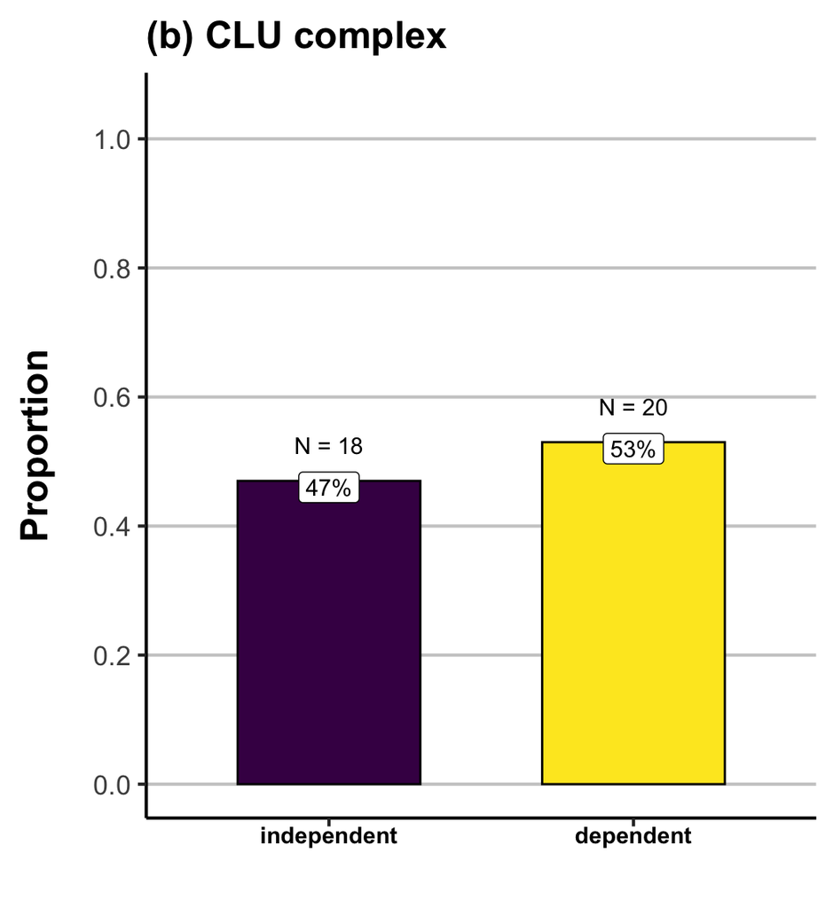

```r
# Data and aesthetics:

complex_p <- compl_subset %>%
  count(CLUcomplex_value, sort = TRUE) %>%
  filter(!is.na(CLUcomplex_value)) %>%
  mutate(Proportion = proportion(n),
         Perc = percentage(n),
         N = str_c('N = ', n)) %>%
  ggplot(aes(x = reorder(CLUcomplex_value, Proportion),
             y = Proportion, fill = reorder(CLUcomplex_value, Proportion)))

# Add geoms:

complex_p <- complex_p +
  geom_bar(stat = 'identity', col = 'black', width = 0.6) +
  geom_text(aes(label = N), nudge_y = 0.055) +
  geom_label(aes(label = Perc), nudge_y = -0.01, fill = 'white')

# Add other plot features:

complex_p <- complex_p +
  scale_fill_viridis_d() +
  scale_y_continuous(breaks = seq(0, 1.0, 0.2), limits = c(0, 1.05)) +
  xlab('') +
  ggtitle('(b) CLU complex') +
  theme_BSL()

# Plot:

complex_p
```

```r
# Save:

ggsave('../figures/CLU_complex.pdf', within_p,
       width = 4.5, height = 5)
ggsave('../figures/CLU_complex.png', within_p,
       width = 4.5, height = 5)
```

```r
CLU_matrix <- matrix(c(1, 1, 1, 1, 1, 1, 1, 2, 2, 2, 2, 2),
                      nrow = 1)
```

Use grid.arrange() to put them both into a plot with the specified matrix.

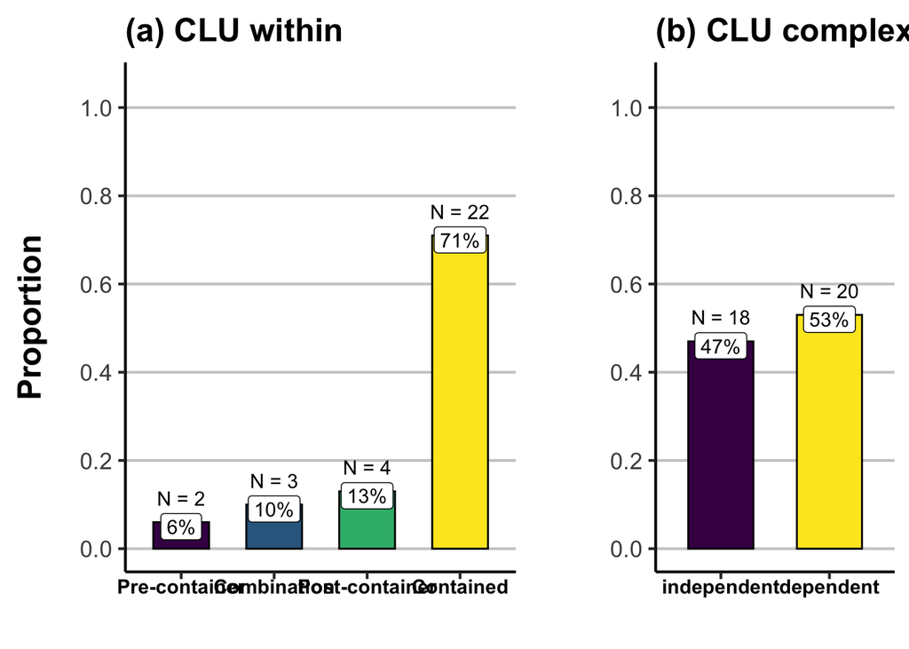

```r
# When included in double plot, we don't need y-axis label for the (b) plot again:

complex_p <- complex_p +
  ylab('')

CLU_subtype_p <- grid.arrange(within_p, complex_p,
                              layout_matrix = CLU_matrix)
```

```r
# Save:

ggsave('../figures/CLU_subtype.pdf', CLU_subtype_p,
       width = 12, height = 5)
ggsave('../figures/CLU_subtype.png', CLU_subtype_p,
       width = 12, height = 5)
```

## Sociolinguistic variation in form

Check whether there’s any association between whether the family has at least one deaf member or not:

```r
# Manual sign:

round(with(both,
           chisq.test(table(Manual_YesNo, Family))$stdres), 2)
```

```
##                 Family
## Manual_YesNo      Deaf Hearing
##   manual sign    -0.04    0.04
##   no manual sign  0.04   -0.04
```

```r
# Regularity of manual sign:

both_reg <- filter(both,
                   Manual_YesNo == 'manual sign',
                   regularity != '?')
round(with(both_reg,
           chisq.test(table(regularity, Family))$stdres), 2)
```

```
##            Family
## regularity  Deaf Hearing
##   Irregular -0.5     0.5
##   Regular    0.5    -0.5
```

```r
# Mouthing:

round(with(both,
           chisq.test(table(Mouthing_YesNo, Family))$stdres), 2)
```

```
##               Family
## Mouthing_YesNo Deaf Hearing
##    mouthing    -0.7     0.7
##    no mouthing  0.7    -0.7
```

```r
# Mouth gesture:

round(with(both,
           chisq.test(table(MouthGesture_YesNo, Family))$stdres), 2)
```

```
##                   Family
## MouthGesture_YesNo  Deaf Hearing
##   Mouth gesture    -1.44    1.44
##   No mouth gesture  1.44   -1.44
```

```r
# Head shake:

round(with(both,
           chisq.test(table(HS_YesNo, Family))$stdres), 2)
```

```
##         Family
## HS_YesNo  Deaf Hearing
##    HS     0.25   -0.25
##    no HS -0.25    0.25
```

Check whether there’s any association between form and location:

```r
# Manual sign:

round(with(both,
           chisq.test(table(Manual_YesNo, Location))$stdres), 2)
```

```
##                 Location
## Manual_YesNo     Birmingham Bristol London Manchester
##   manual sign          0.62   -2.91  -0.60       3.02
##   no manual sign      -0.62    2.91   0.60      -3.02
```

```r
# Mouthing:

round(with(both,
           chisq.test(table(Mouthing_YesNo, Location))$stdres), 2)
```

```
##               Location
## Mouthing_YesNo Birmingham Bristol London Manchester
##    mouthing         -1.56   -0.56  -0.53       2.76
##    no mouthing       1.56    0.56   0.53      -2.76
```

```r
# Regularity of manual sign:

round(with(both_reg,
           chisq.test(table(regularity, Location))$stdres), 2)
```

```
##            Location
## regularity  Birmingham Bristol London Manchester
##   Irregular       1.61    0.00  -0.70      -0.83
##   Regular        -1.61    0.00   0.70       0.83
```

```r
# Mouth gesture:

round(with(both,
           chisq.test(table(MouthGesture_YesNo, Location))$stdres), 2)
```

```
##                   Location
## MouthGesture_YesNo Birmingham Bristol London Manchester
##   Mouth gesture         -0.49    1.48  -0.77      -0.15
##   No mouth gesture       0.49   -1.48   0.77       0.15
```

```r
# Head shake:

round(with(both,
           chisq.test(table(HS_YesNo, Location))$stdres), 2)
```

```
##         Location
## HS_YesNo Birmingham Bristol London Manchester
##    HS          0.92    2.00  -0.33      -2.60
##    no HS      -0.92   -2.00   0.33       2.60
```

For the ‘reliable’ effects, check whether this variation is driven by a few individuals.

Manual signs:

```r
# Location and manual signs: majority:

both %>%
  count(ID, Location, Manual_YesNo) %>%
  pivot_wider(values_from = n,
              names_from = Manual_YesNo,
              values_fill = 0) %>%
  mutate(manual_more = `manual sign` > `no manual sign`) %>%
  count(Location, manual_more) %>%
  pivot_wider(values_from = n,
              names_from = manual_more,
              values_fill = 0)
```

```
## # A tibble: 4 × 3
##   Location   `TRUE` `FALSE`
##   <chr>       <int>   <int>
## 1 Birmingham     10       0
## 2 Bristol         6       4
## 3 London          9       1
## 4 Manchester      9       1
```

Plot of raw percentage:

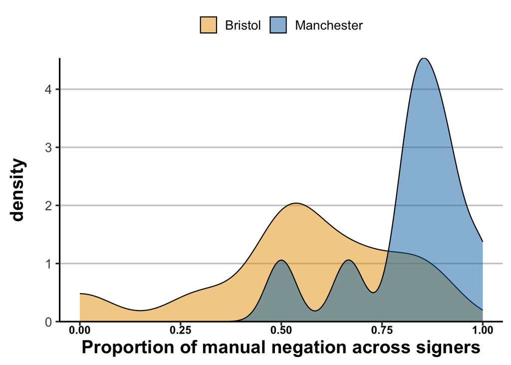

```r
# Raw percentage:

bristol_v_manchester_p <- both %>%
  count(ID, Location, Manual_YesNo) %>%
  pivot_wider(values_from = n,
              names_from = Manual_YesNo,
              values_fill = 0) %>%
  mutate(percentage = `manual sign` / (`manual sign` + `no manual sign`)) %>%
  filter(Location %in% c('Manchester', 'Bristol')) %>%

## Specify ggplot:

  ggplot(aes(x = percentage, fill = Location)) +
  geom_density(alpha = 0.5)

## Add cosmetics:

bristol_v_manchester_p <- bristol_v_manchester_p +
  xlab('Proportion of manual negation across signers') +
  scale_y_continuous(expand = c(0, 0)) +
  scale_fill_manual(values = c("#E69F00", "#0072B2")) +
  theme_BSL() +
  theme(legend.position = 'top',
        legend.title = element_blank())

## Show:

bristol_v_manchester_p
```

```r
## Save:

ggsave(plot = bristol_v_manchester_p,
       filename = '../figures/bristol_v_manchester.pdf',
       width = 8, height = 6)
ggsave(plot = bristol_v_manchester_p,
       filename = '../figures/bristol_v_manchester.png',
       width = 8, height = 6)
```

Version with white text and black background for Gab’s talk:

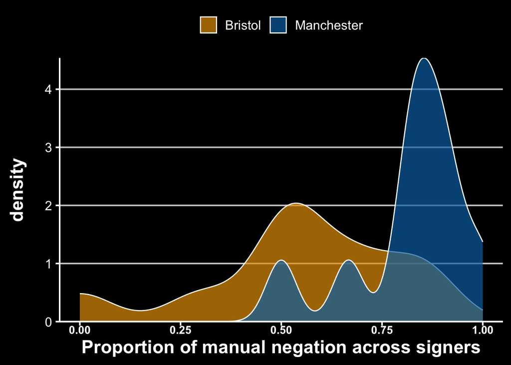

```r
bristol_v_manchester_p <- both %>%
  count(ID, Location, Manual_YesNo) %>%
  pivot_wider(values_from = n,
              names_from = Manual_YesNo,
              values_fill = 0) %>%
  mutate(percentage = `manual sign` / (`manual sign` + `no manual sign`)) %>%
  filter(Location %in% c('Manchester', 'Bristol')) %>%

## Specify ggplot:

  ggplot(aes(x = percentage, fill = Location)) +
  geom_density(alpha = 0.7, col = 'white')

## Add cosmetics:

bristol_v_manchester_p <- bristol_v_manchester_p +
  xlab('Proportion of manual negation across signers') +
  scale_y_continuous(expand = c(0, 0)) +
  scale_fill_manual(values = c("#E69F00", "#0072B2")) +
  theme_BSL() +
  theme(legend.position = 'top',
        legend.title = element_blank(),
        axis.title.x = element_text(color = 'white'),
        axis.title.y = element_text(color = 'white'),
        axis.text.x = element_text(color = 'white'),
        axis.text.y = element_text(color = 'white'),
        legend.text = element_text(color = 'white'),
        panel.background = element_rect(fill = 'black'),
        plot.background = element_rect(fill = 'black',
                                       color = 'black'),
        legend.background = element_rect(fill = 'black'),
        axis.line = element_line(color = 'white'),
        axis.ticks = element_line(color = 'white'))

## Show:

bristol_v_manchester_p
```

```r
ggsave(plot = bristol_v_manchester_p,
       filename = '../figures/bristol_v_manchester_bw.pdf',
       width = 8, height = 6,
       bg = 'transparent')
ggsave(plot = bristol_v_manchester_p,
       filename = '../figures/bristol_v_manchester_bw.png',
       width = 8, height = 6,
       bg = 'transparent')
```

Mouthing:

```r
# Location and manual signs: mouthing:

both %>%
  count(ID, Location, Mouthing_YesNo) %>%
  pivot_wider(values_from = n,
              names_from = Mouthing_YesNo,
              values_fill = 0) %>%
  mutate(more_mouthing = mouthing > `no mouthing`) %>%
  count(Location, more_mouthing) %>%
  pivot_wider(values_from = n,
              names_from = more_mouthing,
              values_fill = 0)
```

```
## # A tibble: 4 × 3
##   Location   `FALSE` `TRUE`
##   <chr>        <int>  <int>
## 1 Birmingham       5      5
## 2 Bristol          5      5
## 3 London           4      6
## 4 Manchester       1      9
```

Plot of raw percentage for mouthing:

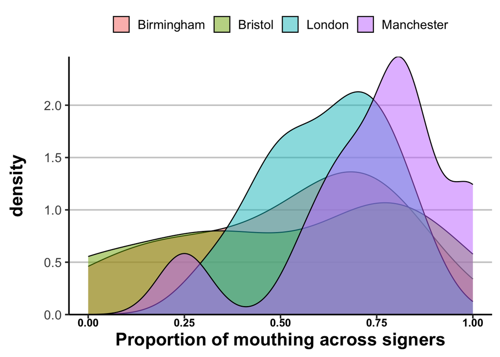

```r
# Raw percentage for manual sign:

mouthing_location_p <- both %>%
  count(ID, Location, Mouthing_YesNo) %>%
  pivot_wider(values_from = n,
              names_from = Mouthing_YesNo,
              values_fill = 0) %>%
  mutate(percentage = mouthing / (mouthing + `no mouthing`)) %>%
  # filter(Location %in% c('Manchester', 'Bristol')) %>%

## Specify ggplot:

  ggplot(aes(x = percentage, fill = Location)) +
  geom_density(alpha = 0.5)

## Add cosmetics:

mouthing_location_p <- mouthing_location_p +
  xlab('Proportion of mouthing across signers') +
  scale_y_continuous(expand = c(0, 0)) +
  # scale_fill_manual(values = c("#E69F00", "#0072B2")) +
  theme_BSL() +
  theme(legend.position = 'top',
        legend.title = element_blank())

# Show:

mouthing_location_p
```

```r
## Save:

ggsave(plot = mouthing_location_p,
       filename = '../figures/mouthing_location.pdf',
       width = 8, height = 6)
ggsave(plot = mouthing_location_p,
       filename = '../figures/mouthing_location.png',
       width = 8, height = 6)
```

Head shakes:

```r
# Location and head shakes: majority:

both %>%
  count(ID, Location, HS_YesNo) %>%
  pivot_wider(values_from = n,
              names_from = HS_YesNo,
              values_fill = 0) %>%
  mutate(HS_more = HS > `no HS`) %>%
  count(Location, HS_more) %>%
  pivot_wider(values_from = n,
              names_from = HS_more,
              values_fill = 0)
```

```
## # A tibble: 4 × 3
##   Location   `TRUE` `FALSE`
##   <chr>       <int>   <int>
## 1 Birmingham     10       0
## 2 Bristol        10       0
## 3 London         10       0
## 4 Manchester      9       1
```

Hard to see any differences since the majority used head shakes all the time.

Plot of raw percentage:

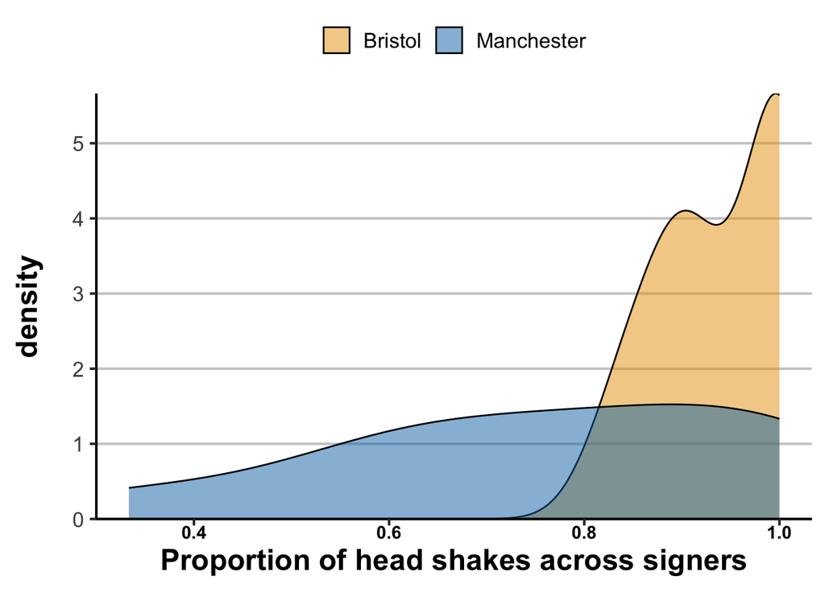

```r
# Raw percentage:

bristol_v_manchester_HS_p <- both %>%
  count(ID, Location, HS_YesNo) %>%
  pivot_wider(values_from = n,
              names_from = HS_YesNo,
              values_fill = 0) %>%
  mutate(percentage = HS / (HS + `no HS`)) %>%
  filter(Location %in% c('Manchester', 'Bristol')) %>%

## Specify ggplot:

  ggplot(aes(x = percentage, fill = Location)) +
  geom_density(alpha = 0.5)

## Add cosmetics:

bristol_v_manchester_HS_p <- bristol_v_manchester_HS_p +
  xlab('Proportion of head shakes across signers') +
  scale_y_continuous(expand = c(0, 0)) +
  scale_fill_manual(values = c("#E69F00", "#0072B2")) +
  theme_BSL() +
  theme(legend.position = 'top',
        legend.title = element_blank())

## Show:

bristol_v_manchester_HS_p
```

```r
## Save:

ggsave(plot = bristol_v_manchester_HS_p,
       filename = '../figures/bristol_v_manchester_head_shakes.pdf',
       width = 8, height = 6)
ggsave(plot = bristol_v_manchester_HS_p,
       filename = '../figures/bristol_v_manchester_head_shakes.png',
       width = 8, height = 6)
```

Make a black and white version of this for Gab’s talk:

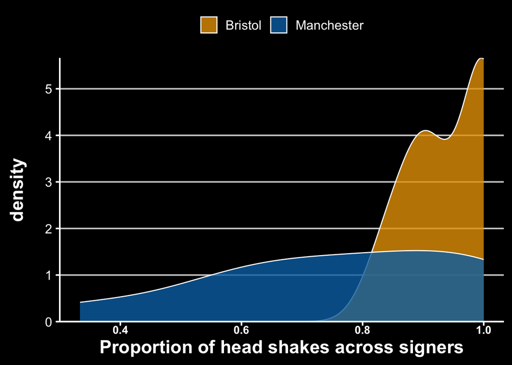

```r
# Raw percentage:

bristol_v_manchester_HS_p <- both %>%
  count(ID, Location, HS_YesNo) %>%
  pivot_wider(values_from = n,
              names_from = HS_YesNo,
              values_fill = 0) %>%
  mutate(percentage = HS / (HS + `no HS`)) %>%
  filter(Location %in% c('Manchester', 'Bristol')) %>%

## Specify ggplot:

  ggplot(aes(x = percentage, fill = Location)) +
  geom_density(alpha = 0.8, col = 'white')

## Add cosmetics:

bristol_v_manchester_HS_p <- bristol_v_manchester_HS_p +
  xlab('Proportion of head shakes across signers') +
  scale_y_continuous(expand = c(0, 0)) +
  scale_fill_manual(values = c("#E69F00", "#0072B2")) +
  theme_BSL() +
  theme(legend.position = 'top',
        legend.title = element_blank(),
        axis.title.x = element_text(color = 'white'),
        axis.title.y = element_text(color = 'white'),
        axis.text.x = element_text(color = 'white'),
        axis.text.y = element_text(color = 'white'),
        legend.text = element_text(color = 'white'),
        panel.background = element_rect(fill = 'black'),
        plot.background = element_rect(fill = 'black',
                                       color = 'black'),
        legend.background = element_rect(fill = 'black'),
        axis.line = element_line(color = 'white'),
        axis.ticks = element_line(color = 'white'))

## Show:

bristol_v_manchester_HS_p
```

```r
## Save:

ggsave(plot = bristol_v_manchester_HS_p,
       filename = '../figures/bristol_v_manchester_head_shakes_bw.pdf',
       width = 8, height = 6)
ggsave(plot = bristol_v_manchester_HS_p,
       filename = '../figures/bristol_v_manchester_head_shakes_bw.png',
       width = 8, height = 6)
```

Put both of the Bristol v Manchester graphs into an a) and b) version:

```r
## Add titles:

bristol_v_manchester_p <- bristol_v_manchester_p +
  ggtitle('(a) Manual negation')
bristol_v_manchester_HS_p <- bristol_v_manchester_HS_p +
  ggtitle('(b) Head shakes')

## Put together:

location_both_p <- bristol_v_manchester_p + bristol_v_manchester_HS_p

## Save:

ggsave(plot = location_both_p, filename = '../figures/location_both.pdf',
       width = 13, height = 4.5)
ggsave(plot = location_both_p, filename = '../figures/location_both.png',
       width = 13, height = 4.5)
```

Check whether there’s any association between form and gender:

```r
# Manual sign:

round(with(both,
           chisq.test(table(Manual_YesNo, Gender))$stdres), 2)
```

```
##                 Gender
## Manual_YesNo         F     M
##   manual sign    -1.02  1.02
##   no manual sign  1.02 -1.02
```

```r
# Regular negation:

round(with(both_reg,
           chisq.test(table(regularity, Gender))$stdres), 2)
```

```
##            Gender
## regularity      F     M
##   Irregular -0.26  0.26
##   Regular    0.26 -0.26
```

```r
# Mouthing:

round(with(both,
           chisq.test(table(Mouthing_YesNo, Gender))$stdres), 2)
```

```
##               Gender
## Mouthing_YesNo     F     M
##    mouthing     1.02 -1.02
##    no mouthing -1.02  1.02
```

```r
# Mouth gesture:

round(with(both,
           chisq.test(table(MouthGesture_YesNo, Gender))$stdres), 2)
```

```
##                   Gender
## MouthGesture_YesNo    F    M
##   Mouth gesture    -0.2  0.2
##   No mouth gesture  0.2 -0.2
```

```r
# Head shake:

round(with(both,
           chisq.test(table(HS_YesNo, Gender))$stdres), 2)
```

```
##         Gender
## HS_YesNo    F    M
##    HS     0.6 -0.6
##    no HS -0.6  0.6
```

Check whether there’s any association between form and age group:

```r
# What is the median age?

median(both$Age)
```

```
## [1] 45
```

```r
# Perform a median split, as well as a 20-30, 40-50, and 60+ split:

both <- mutate(both,
              AgeMedianSplit = ifelse(Age > median(Age), 'old', 'young'),
              AgeSplit = ifelse(Age < 30, '<30', Age),
              AgeSplit = ifelse(AgeSplit >= 30 & AgeSplit < 60, '30-60', AgeSplit),
              AgeSplit = ifelse(AgeSplit >= 60, '60+', AgeSplit))

# Manual sign:

round(with(both,
           chisq.test(table(Manual_YesNo, AgeSplit))$stdres), 2)
```

```
##                 AgeSplit
## Manual_YesNo       <30 30-60   60+
##   manual sign     2.43 -2.27  0.47
##   no manual sign -2.43  2.27 -0.47
```

```r
# Regular negation:

both_reg <- filter(both,
                   Manual_YesNo == 'manual sign',
                   regularity != '?')
round(with(both_reg,
           chisq.test(table(regularity, AgeSplit))$stdres), 2)
```

```
##            AgeSplit
## regularity    <30 30-60   60+
##   Irregular  0.65  0.47 -1.11
##   Regular   -0.65 -0.47  1.11
```

```r
# Mouthing:

round(with(both,
           chisq.test(table(Mouthing_YesNo, AgeSplit))$stdres), 2)
```

```
##               AgeSplit
## Mouthing_YesNo   <30 30-60   60+
##    mouthing    -0.27 -1.98  2.37
##    no mouthing  0.27  1.98 -2.37
```

```r
# Mouth gesture:

round(with(both,
           chisq.test(table(MouthGesture_YesNo, AgeSplit))$stdres), 2)
```

```
##                   AgeSplit
## MouthGesture_YesNo   <30 30-60   60+
##   Mouth gesture    -0.67  1.59 -1.18
##   No mouth gesture  0.67 -1.59  1.18
```

```r
# Head shake:

round(with(both,
           chisq.test(table(HS_YesNo, AgeSplit))$stdres), 2)
```

```
##         AgeSplit
## HS_YesNo   <30 30-60   60+
##    HS    -0.98  2.80 -2.24
##    no HS  0.98 -2.80  2.24
```

Check this for different signers:

Plot of raw percentage for manual signs:

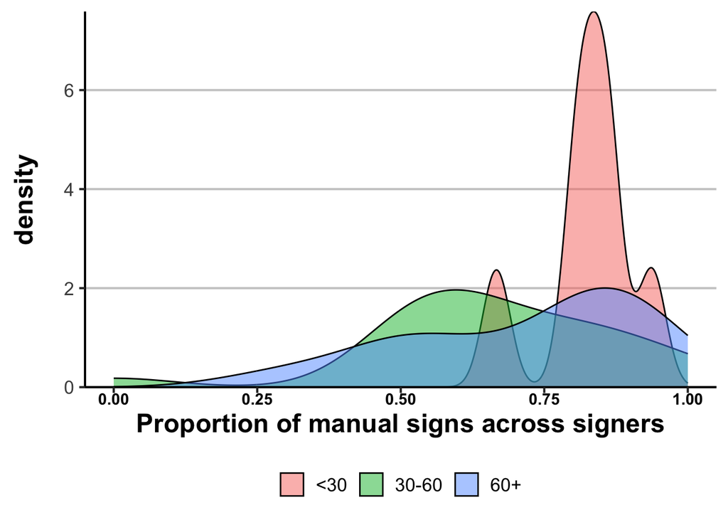

```r
# Raw percentage:

age_manual_p <- both %>%
  count(ID, AgeSplit, Manual_YesNo) %>%
  pivot_wider(values_from = n,
              names_from = Manual_YesNo,
              values_fill = 0) %>%
  mutate(percentage = `manual sign` / (`manual sign` + `no manual sign`)) %>%

## Specify ggplot:

  ggplot(aes(x = percentage, fill = AgeSplit)) +
  geom_density(alpha = 0.5)

## Add cosmetics:

age_manual_p <- age_manual_p +
  xlab('Proportion of manual signs across signers') +
  scale_y_continuous(expand = c(0, 0)) +
  # scale_fill_manual(values = c("#E69F00", "#0072B2")) +
  theme_BSL() +
  theme(legend.position = 'bottom',
        legend.title = element_blank())

## Show:

age_manual_p
```

```r
## Save:

ggsave(plot = age_manual_p,
       filename = '../figures/age_manual.pdf',
       width = 8, height = 6)
ggsave(plot = age_manual_p,
       filename = '../figures/age_manual.png',
       width = 8, height = 6)
```

Mouthing:

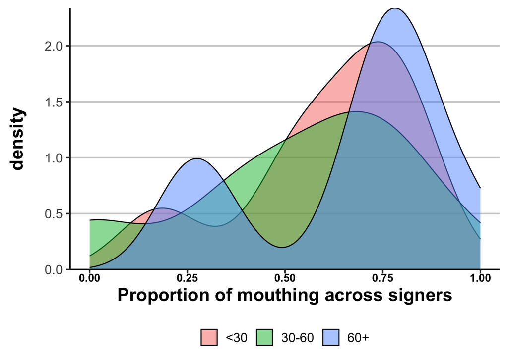

```r
# Raw percentage:

age_mouthing_p <- both %>%
  count(ID, AgeSplit, Mouthing_YesNo) %>%
  pivot_wider(values_from = n,
              names_from = Mouthing_YesNo,
              values_fill = 0) %>%
  mutate(percentage = mouthing / (mouthing + `no mouthing`)) %>%

## Specify ggplot:

  ggplot(aes(x = percentage, fill = AgeSplit)) +
  geom_density(alpha = 0.5)

## Add cosmetics:

age_mouthing_p <- age_mouthing_p +
  xlab('Proportion of mouthing across signers') +
  scale_y_continuous(expand = c(0, 0)) +
  # scale_fill_manual(values = c("#E69F00", "#0072B2")) +
  theme_BSL() +
  theme(legend.position = 'bottom',
        legend.title = element_blank())

## Show:

age_mouthing_p
```

```r
## Save:

ggsave(plot = age_mouthing_p,
       filename = '../figures/age_mouthing.pdf',
       width = 8, height = 6)
ggsave(plot = age_mouthing_p,
       filename = '../figures/age_mouthing.png',
       width = 8, height = 6)
```

Head shakes:

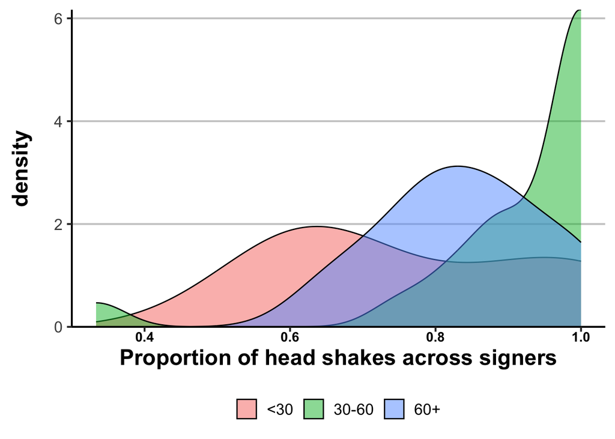

```r
# Raw percentage:

age_HS_p <- both %>%
  count(ID, AgeSplit, HS_YesNo) %>%
  pivot_wider(values_from = n,
              names_from = HS_YesNo,
              values_fill = 0) %>%
  mutate(percentage = HS / (HS + `no HS`)) %>%

## Specify ggplot:

  ggplot(aes(x = percentage, fill = AgeSplit)) +
  geom_density(alpha = 0.5)

## Add cosmetics:

age_HS_p <- age_HS_p +
  xlab('Proportion of head shakes across signers') +
  scale_y_continuous(expand = c(0, 0)) +
  # scale_fill_manual(values = c("#E69F00", "#0072B2")) +
  theme_BSL() +
  theme(legend.position = 'bottom',
        legend.title = element_blank())

## Show:

age_HS_p
```

```r
## Save:

ggsave(plot = age_HS_p,
       filename = '../figures/age_manual.pdf',
       width = 8, height = 6)
ggsave(plot = age_HS_p,
       filename = '../figures/age_manual.png',
       width = 8, height = 6)
```

Put them all into one plot:

```r
# Add titles:

age_manual_p <- age_manual_p + ggtitle('(a) Manual signs')
age_mouthing_p <- age_mouthing_p + ggtitle('(b) Mouthing')
age_HS_p <- age_HS_p + ggtitle('(c) Head shakes')

# Put them all together:

three_p <- age_manual_p + age_mouthing_p +
  age_HS_p + plot_layout(nrow = 2)

# Save:

ggsave(plot = three_p, filename = '../figures/age_three_plot.pdf',
       width = 12, height = 8)
ggsave(plot = three_p, filename = '../figures/age_three_plot.png',
       width = 12, height = 8)
```

How is age distributed across gender? (to assess feasibility of looking for interactions)

```r
both %>%
  count(AgeSplit, Gender, ID) %>%
  count(AgeSplit, Gender)
```

```
## # A tibble: 6 × 3
##   AgeSplit Gender     n
##   <chr>    <chr>  <int>
## 1 30-60    F         14
## 2 30-60    M          7
## 3 60+      F          4
## 4 60+      M          8
## 5 <30      F          2
## 6 <30      M          5
```

Very uneven distribution. Will be hard to draw any inferences about how these two factors hang together.

How is age distributed across location? (to assess feasibility of looking for interactions)

```r
both %>%
  count(AgeSplit, Location, ID) %>%
  count(Location, AgeSplit)
```

```
## # A tibble: 11 × 3
##    Location   AgeSplit     n
##    <chr>      <chr>    <int>
##  1 Birmingham 30-60        6
##  2 Birmingham 60+          2
##  3 Birmingham <30          2
##  4 Bristol    30-60        6
##  5 Bristol    60+          3
##  6 Bristol    <30          1
##  7 London     30-60        8
##  8 London     60+          2
##  9 Manchester 30-60        1
## 10 Manchester 60+          5
## 11 Manchester <30          4
```

Very uneven distribution. Will be hard to draw any inferences about how these two factors hang together.

Check whether there’s any association between form and BSL teaching:

```r
# Manual sign:

round(with(both,
           chisq.test(table(Manual_YesNo, Taught_BSL_YesNo))$stdres), 2)
```

```
##                 Taught_BSL_YesNo
## Manual_YesNo         N     Y
##   manual sign     0.69 -0.69
##   no manual sign -0.69  0.69
```

```r
# Mouthing:

round(with(both,
           chisq.test(table(Mouthing_YesNo, Taught_BSL_YesNo))$stdres), 2)
```

```
##               Taught_BSL_YesNo
## Mouthing_YesNo     N     Y
##    mouthing     3.27 -3.27
##    no mouthing -3.27  3.27
```

```r
# Mouth gesture:

round(with(both,
           chisq.test(table(MouthGesture_YesNo, Taught_BSL_YesNo))$stdres), 2)
```

```
##                   Taught_BSL_YesNo
## MouthGesture_YesNo     N     Y
##   Mouth gesture    -3.24  3.24
##   No mouth gesture  3.24 -3.24
```

```r
# Head shake:

round(with(both,
           chisq.test(table(HS_YesNo, Taught_BSL_YesNo))$stdres), 2)
```

```
##         Taught_BSL_YesNo
## HS_YesNo     N     Y
##    HS    -1.22  1.22
##    no HS  1.22 -1.22
```

Mouthings per teaching:

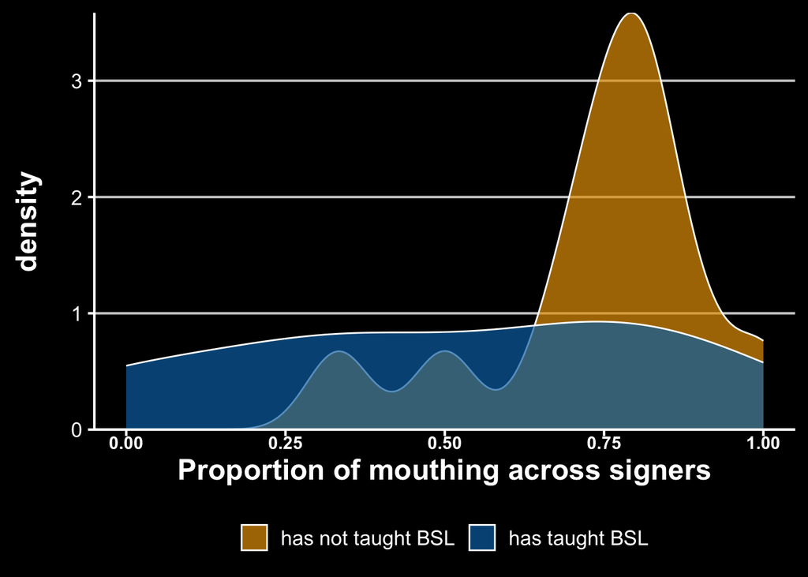

```r
# Raw percentage:

teaching_mouthing_p <- both %>%
  count(ID, Taught_BSL_YesNo, Mouthing_YesNo) %>%
  pivot_wider(values_from = n,
              names_from = Mouthing_YesNo,
              values_fill = 0) %>%
  mutate(percentage = mouthing / (mouthing + `no mouthing`)) %>%
  filter(!is.na(Taught_BSL_YesNo)) %>%
  mutate(Taught_BSL_YesNo = ifelse(Taught_BSL_YesNo == 'Y',
                                   'has taught BSL',
                                   'has not taught BSL')) %>%

## Specify ggplot:

  ggplot(aes(x = percentage, fill = Taught_BSL_YesNo)) +
  # geom_density(alpha = 0.5) +
  geom_density(alpha = 0.7, color = 'white')

## Add cosmetics:

teaching_mouthing_p <- teaching_mouthing_p +
  xlab('Proportion of mouthing across signers') +
  scale_y_continuous(expand = c(0, 0)) +
  scale_fill_manual(values = c("#E69F00", "#0072B2")) +
  theme_BSL() +
  # theme(legend.position = 'bottom',
  #       legend.title = element_blank()) +
    theme(legend.position = 'bottom', # black and white version
        legend.title = element_blank(),
        axis.title.x = element_text(color = 'white'),
        axis.title.y = element_text(color = 'white'),
        axis.text.x = element_text(color = 'white'),
        axis.text.y = element_text(color = 'white'),
        legend.text = element_text(color = 'white'),
        panel.background = element_rect(fill = 'black'),
        plot.background = element_rect(fill = 'black',
                                       color = 'black'),
        legend.background = element_rect(fill = 'black'),
        axis.line = element_line(color = 'white'),
        axis.ticks = element_line(color = 'white'))

## Show:

teaching_mouthing_p
```

```r
## Save:

ggsave(plot = teaching_mouthing_p,
       filename = '../figures/teaching_mouthing.pdf',
       width = 8, height = 6)
ggsave(plot = teaching_mouthing_p,
       filename = '../figures/teaching_mouthing.png',
       width = 8, height = 6)
```

Mouth gestures per teaching:

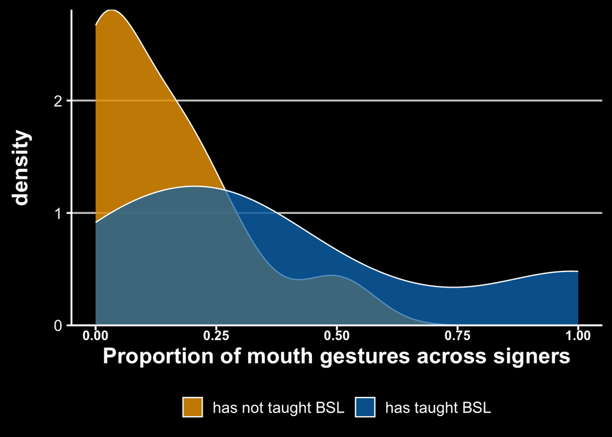

```r
# Raw percentage:

teaching_mouth_gesture_p <- both %>%
  count(ID, Taught_BSL_YesNo, MouthGesture_YesNo) %>%
  pivot_wider(values_from = n,
              names_from = MouthGesture_YesNo,
              values_fill = 0) %>%
  mutate(percentage = `Mouth gesture` / (`Mouth gesture` + `No mouth gesture`)) %>%
  filter(!is.na(Taught_BSL_YesNo)) %>%
  mutate(Taught_BSL_YesNo = ifelse(Taught_BSL_YesNo == 'Y',
                                   'has taught BSL',
                                   'has not taught BSL')) %>%

## Specify ggplot:

  ggplot(aes(x = percentage, fill = Taught_BSL_YesNo)) +
  geom_density(alpha = 0.5) +
  geom_density(alpha = 0.7, color = 'white')

## Add cosmetics:

teaching_mouth_gesture_p <- teaching_mouth_gesture_p +
  xlab('Proportion of mouth gestures across signers') +
  scale_y_continuous(expand = c(0, 0)) +
  scale_fill_manual(values = c("#E69F00", "#0072B2")) +
  theme_BSL() +
  # theme(legend.position = 'bottom',
  #       legend.title = element_blank()) +
  theme(legend.position = 'bottom', # black and white version
        legend.title = element_blank(),
        axis.title.x = element_text(color = 'white'),
        axis.title.y = element_text(color = 'white'),
        axis.text.x = element_text(color = 'white'),
        axis.text.y = element_text(color = 'white'),
        legend.text = element_text(color = 'white'),
        panel.background = element_rect(fill = 'black'),
        plot.background = element_rect(fill = 'black',
                                       color = 'black'),
        legend.background = element_rect(fill = 'black'),
        axis.line = element_line(color = 'white'),
        axis.ticks = element_line(color = 'white'))

## Show:

teaching_mouth_gesture_p
```

```r
## Save:

ggsave(plot = teaching_mouth_gesture_p,
       filename = '../figures/teaching_mouth_gestures.pdf',
       width = 8, height = 6)
ggsave(plot = teaching_mouth_gesture_p,
       filename = '../figures/teaching_mouth_gestures.png',
       width = 8, height = 6)
```

Put both together into one plot:

```r
## Add titles:

teaching_mouthing_p <- teaching_mouthing_p +
  ggtitle('(a) Mouthing')
teaching_mouth_gesture_p <- teaching_mouth_gesture_p +
  ggtitle('(b) Mouth gestures')

## Put both together:

teaching_both_p <- teaching_mouthing_p + teaching_mouth_gesture_p

## Save:

ggsave(plot = teaching_both_p, filename = '../figures/teaching_both.pdf',
       width = 12, height = 4.5)
ggsave(plot = teaching_both_p, filename = '../figures/teaching_both.png',
       width = 12, height = 4.5)
```

## Analysis of regularity

This is new material as of October 21, 2022, after revisions. Reviewers asked for an analysis of regular versus irregular negation, which we now supply. The annotation was done by Adam.

Check overall frequency of regular versus irregular negation:

```r
neg %>%
  filter(Manual_YesNo == 'manual sign') %>%
  count(regularity) %>%
  mutate(Perc = percentage(n))
```

```
## # A tibble: 3 × 3
##   regularity     n Perc
##   <chr>      <int> <chr>
## 1 ?             19 8%
## 2 Irregular     82 35%
## 3 Regular      132 57%
```

Check whether head shakes vary as a function of regular versus irregular negation:

```r
neg %>%
  filter(Manual_YesNo == 'manual sign') %>%
  count(regularity, HS_YesNo) %>%
  group_by(regularity) %>%
  mutate(Perc = percentage(n))
```

```
## # A tibble: 6 × 4
## # Groups:   regularity [3]
##   regularity HS_YesNo     n Perc
##   <chr>      <chr>    <int> <chr>
## 1 ?          HS          14 74%
## 2 ?          no HS        5 26%
## 3 Irregular  HS          62 76%
## 4 Irregular  no HS       20 24%
## 5 Regular    HS         119 90%
## 6 Regular    no HS       13 10%
```